# Reasonableness_Medians_072025

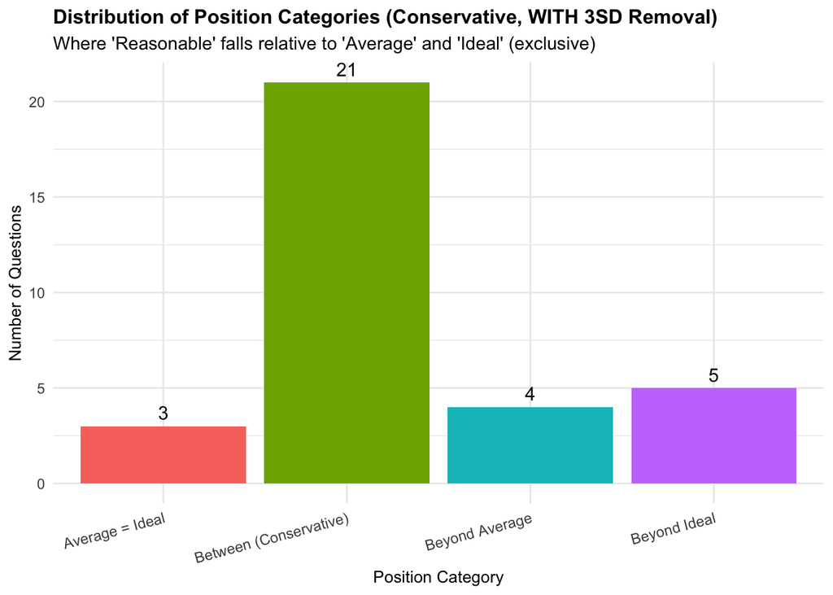

```r
position_distribution_plot_conservative_3sd <- ggplot(position_counts_conservative_3sd, aes(x = Position, y = Count, fill = Position)) +
  geom_bar(stat = "identity") +
  geom_text(aes(label = paste0(Count)), vjust = -0.5, size = 4) +
  labs(title = "Distribution of Position Categories (Conservative, WITH 3SD Removal)",
       subtitle = "Where 'Reasonable' falls relative to 'Average' and 'Ideal' (exclusive)",
       x = "Position Category", y = "Number of Questions") +
  theme_minimal() + theme( plot.title = element_text(size = 12, face = "bold"), plot.subtitle = element_text(size = 11), axis.title = element_text(size = 10), axis.text.x = element_text(size = 9, angle = 15, hjust = 1), legend.position = "none")
print(position_distribution_plot_conservative_3sd)
```

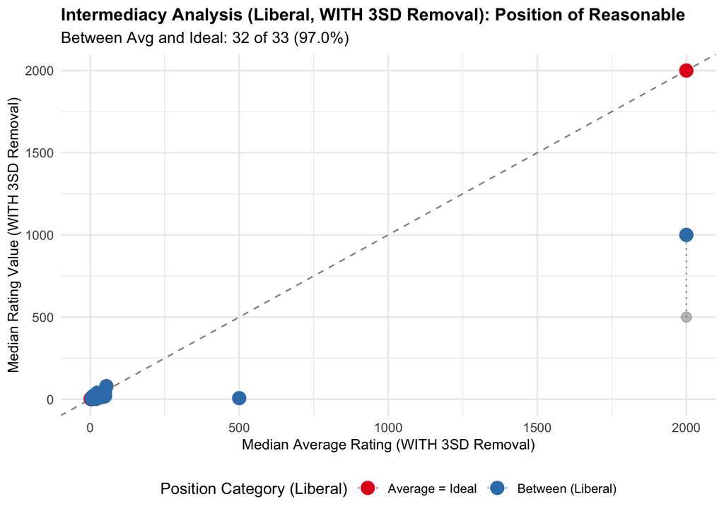

```r
ggsave("position_distribution_median_conservative_3sd_removed.png", position_distribution_plot_conservative_3sd, width = 10, height = 7, dpi = 300)

# --- Liberal Scatterplot ---
plot_data_intermediacy_3sd <- question_position_summary_median_3sd %>% filter(!is.na(Average_Value) & !is.na(Ideal_Value) & !is.na(Reasonable_Value))
prop_both_liberal_3sd_fmt <- scales::percent(ifelse(valid_questions_both_3sd_liberal > 0, count_both_sides_median_3sd_liberal/valid_questions_both_3sd_liberal, 0), accuracy=0.1)

intermediacy_plot_liberal_3sd <- ggplot(plot_data_intermediacy_3sd, aes(x = Average_Value, y = Ideal_Value)) +
  geom_abline(intercept = 0, slope = 1, linetype = "dashed", alpha = 0.5) +
  geom_point(color = "gray60", size = 3, alpha = 0.6) +
  geom_point(aes(x = Average_Value, y = Reasonable_Value, color = Position_Liberal), size = 4) +
  geom_segment(aes(x = Average_Value, xend = Average_Value, y = Ideal_Value, yend = Reasonable_Value, color = Position_Liberal), linetype = "dotted", size = 0.5, alpha = 0.7) +
  scale_color_brewer(palette = "Set1") +
  labs(title = "Intermediacy Analysis (Liberal, WITH 3SD Removal): Position of Reasonable",
       subtitle = paste0("Between Avg and Ideal: ", count_both_sides_median_3sd_liberal, " of ", valid_questions_both_3sd_liberal, " (", prop_both_liberal_3sd_fmt, ")"),
       x = "Median Average Rating (WITH 3SD Removal)", y = "Median Rating Value (WITH 3SD Removal)", color = "Position Category (Liberal)") +
  theme_minimal() + theme(plot.title = element_text(size = 12, face = "bold"), plot.subtitle = element_text(size = 11), axis.title = element_text(size = 10), axis.text = element_text(size = 9), legend.position = "bottom")
print(intermediacy_plot_liberal_3sd)
```

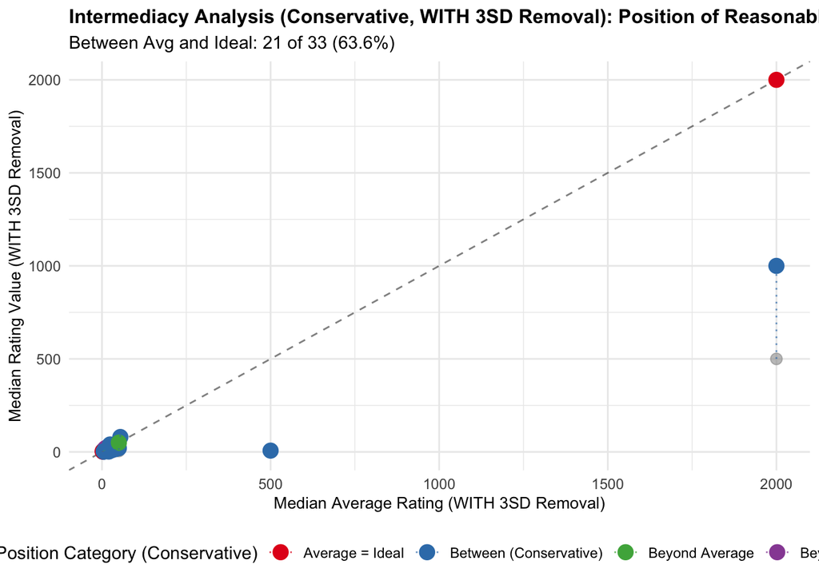

```r
ggsave("intermediacy_analysis_median_liberal_3sd_removed.png", intermediacy_plot_liberal_3sd, width = 10, height = 8, dpi = 300)


# --- Conservative Scatterplot ---
prop_both_conservative_3sd_fmt <- scales::percent(ifelse(valid_questions_both_3sd_conservative > 0, count_both_sides_median_3sd_conservative/valid_questions_both_3sd_conservative, 0), accuracy=0.1)

intermediacy_plot_conservative_3sd <- ggplot(plot_data_intermediacy_3sd, aes(x = Average_Value, y = Ideal_Value)) +
  geom_abline(intercept = 0, slope = 1, linetype = "dashed", alpha = 0.5) +
  geom_point(color = "gray60", size = 3, alpha = 0.6) +
  geom_point(aes(x = Average_Value, y = Reasonable_Value, color = Position_Conservative), size = 4) +
  geom_segment(aes(x = Average_Value, xend = Average_Value, y = Ideal_Value, yend = Reasonable_Value, color = Position_Conservative), linetype = "dotted", size = 0.5, alpha = 0.7) +
  scale_color_brewer(palette = "Set1") +
  labs(title = "Intermediacy Analysis (Conservative, WITH 3SD Removal): Position of Reasonable",
       subtitle = paste0("Between Avg and Ideal: ", count_both_sides_median_3sd_conservative, " of ", valid_questions_both_3sd_conservative, " (", prop_both_conservative_3sd_fmt, ")"),
       x = "Median Average Rating (WITH 3SD Removal)", y = "Median Rating Value (WITH 3SD Removal)", color = "Position Category (Conservative)") +
  theme_minimal() + theme(plot.title = element_text(size = 12, face = "bold"), plot.subtitle = element_text(size = 11), axis.title = element_text(size = 10), axis.text = element_text(size = 9), legend.position = "bottom")
print(intermediacy_plot_conservative_3sd)
```

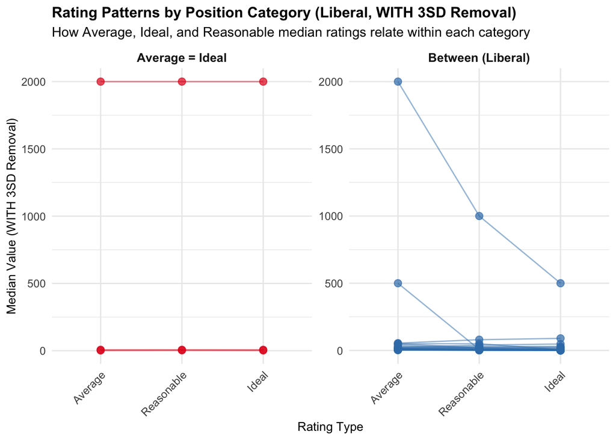

```r
ggsave("intermediacy_analysis_median_conservative_3sd_removed.png", intermediacy_plot_conservative_3sd, width = 10, height = 8, dpi = 300)

# --- Liberal Rating Patterns Plot ---
ratings_long_liberal_3sd <- question_position_summary_median_3sd %>%
  select(Question, Average_Value, Ideal_Value, Reasonable_Value, Position_Liberal) %>%
  pivot_longer(cols = c(Average_Value, Ideal_Value, Reasonable_Value), names_to = "Rating_Type", values_to = "Value") %>%
  mutate(Rating_Type = factor(gsub("_Value", "", Rating_Type), levels = c("Average", "Reasonable", "Ideal"))) %>%
  filter(!is.na(Value))

rating_patterns_plot_liberal_3sd <- ggplot(ratings_long_liberal_3sd, aes(x = Rating_Type, y = Value, group = Question, color = Position_Liberal)) +
  geom_line(alpha = 0.5) + geom_point(size = 2.5, alpha=0.7) + facet_wrap(~ Position_Liberal, scales = "free_y") +
  scale_color_brewer(palette = "Set1") +
  labs(title = "Rating Patterns by Position Category (Liberal, WITH 3SD Removal)",
       subtitle = "How Average, Ideal, and Reasonable median ratings relate within each category",
       x = "Rating Type", y = "Median Value (WITH 3SD Removal)") +
  theme_minimal() + theme(plot.title = element_text(size = 12, face = "bold"), plot.subtitle = element_text(size = 11), axis.title = element_text(size = 10), axis.text.x = element_text(size = 9, angle = 45, hjust = 1), axis.text.y = element_text(size = 9), strip.text = element_text(size=10, face="bold"), legend.position = "none")
print(rating_patterns_plot_liberal_3sd)
```

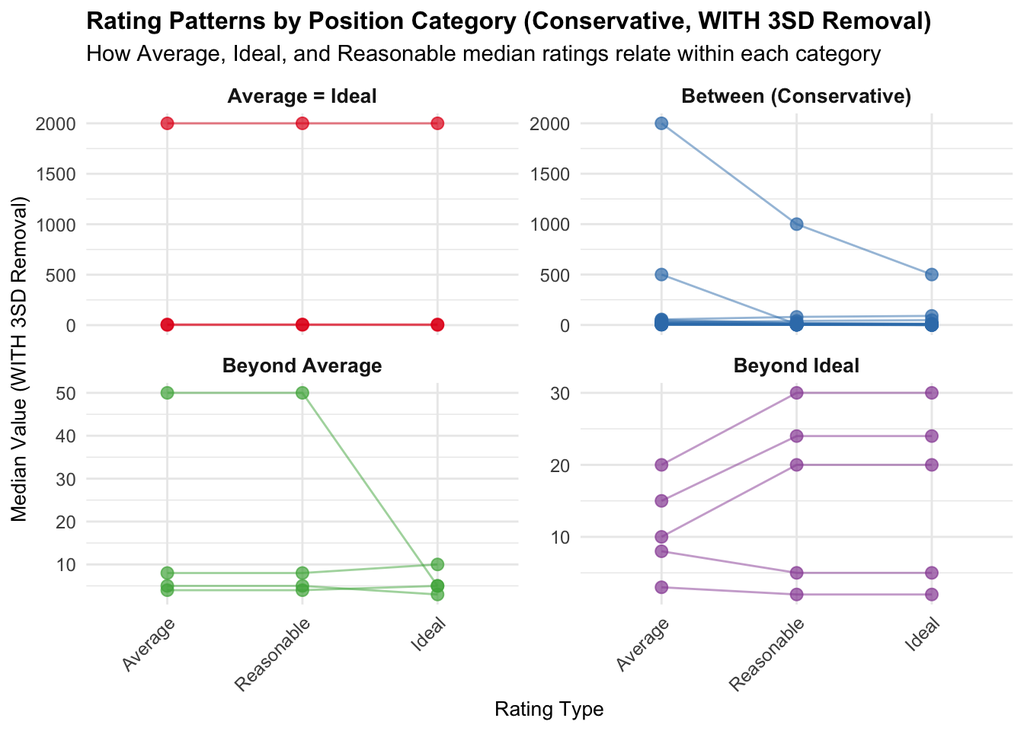

```r
ggsave("rating_patterns_by_position_liberal_3sd_removed.png", rating_patterns_plot_liberal_3sd, width = 12, height = 8, dpi = 300)


# --- Conservative Rating Patterns Plot ---
ratings_long_conservative_3sd <- question_position_summary_median_3sd %>%
  select(Question, Average_Value, Ideal_Value, Reasonable_Value, Position_Conservative) %>%
  pivot_longer(cols = c(Average_Value, Ideal_Value, Reasonable_Value), names_to = "Rating_Type", values_to = "Value") %>%
  mutate(Rating_Type = factor(gsub("_Value", "", Rating_Type), levels = c("Average", "Reasonable", "Ideal"))) %>%
  filter(!is.na(Value))

rating_patterns_plot_conservative_3sd <- ggplot(ratings_long_conservative_3sd, aes(x = Rating_Type, y = Value, group = Question, color = Position_Conservative)) +
  geom_line(alpha = 0.5) + geom_point(size = 2.5, alpha=0.7) + facet_wrap(~ Position_Conservative, scales = "free_y") +
  scale_color_brewer(palette = "Set1") +
  labs(title = "Rating Patterns by Position Category (Conservative, WITH 3SD Removal)",
       subtitle = "How Average, Ideal, and Reasonable median ratings relate within each category",
       x = "Rating Type", y = "Median Value (WITH 3SD Removal)") +
  theme_minimal() + theme(plot.title = element_text(size = 12, face = "bold"), plot.subtitle = element_text(size = 11), axis.title = element_text(size = 10), axis.text.x = element_text(size = 9, angle = 45, hjust = 1), axis.text.y = element_text(size = 9), strip.text = element_text(size=10, face="bold"), legend.position = "none")
print(rating_patterns_plot_conservative_3sd)
```

```r
ggsave("rating_patterns_by_position_conservative_3sd_removed.png", rating_patterns_plot_conservative_3sd, width = 12, height = 8, dpi = 300)

# Store results for this entire analysis chunk
analysis_4_results_3sd <- list(
  ideal_side = list(vector=ideal_side_vector_median_3sd, count=count_ideal_side_median_3sd, valid_n=valid_questions_ideal_3sd, binomial_test=binomial_result_ideal_median_3sd),
  average_side = list(vector=average_side_vector_median_3sd, count=count_average_side_median_3sd, valid_n=valid_questions_avg_3sd, binomial_test=binomial_result_avg_side_median_3sd),
  both_sides_liberal = list(vector=both_sides_vector_median_3sd_liberal, count=count_both_sides_median_3sd_liberal, valid_n=valid_questions_both_3sd_liberal, binomial_test=binomial_result_both_sides_liberal_median_3sd),
  both_sides_conservative = list(vector=both_sides_vector_median_3sd_conservative, count=count_both_sides_median_3sd_conservative, valid_n=valid_questions_both_3sd_conservative, binomial_test=binomial_result_both_sides_conservative_median_3sd),
  combined_summary = intermediacy_summary_3sd,
  question_position_summary = question_position_summary_median_3sd
)
```

# Analysis 7 [NO 3 SD Removed]

```r
# Get unique country names
countries <- unique(Data_All$Country_name)
print(countries)
```

```
##  [1] "USA"         "Colombia"    "Brazil"      "Germany"     "India"
##  [6] "Lithuania"   "Italy"       "Poland"      "Spain"       "Netherlands"
```

#### 7a (Small constant inf values): Country Regressions (NO 3SD Removal)

```r
# Create storage
country_results_median_no3sd_smallval <- list()

# Function to analyze median data for a single country (NO 3SD, Small Constant Log)
analyze_country_median_no3sd_smallval <- function(country, data_avg, data_ideal, data_reas, q_cols) {
  cat("\n========== Analyzing Median Data (NO 3SD, Log Small Const) for:", country, "==========\n")

  # Filter data by country AND apply attention check (using _Pass1 data)
  country_average_pass <- data_avg %>% filter(Country_name == country, q19 == 15)
  country_ideal_pass <- data_ideal %>% filter(Country_name == country, q19 == 15)
  country_reasonable_pass <- data_reas %>% filter(Country_name == country, q19 == 15)

  n_avg <- nrow(country_average_pass)
  n_ideal <- nrow(country_ideal_pass)
  n_reas <- nrow(country_reasonable_pass)

  cat("Participants after attention check:", n_avg, n_ideal, n_reas, "\n")

  if(n_avg < 1 || n_ideal < 1 || n_reas < 1) {
      cat("Insufficient participants for", country, "\n"); return(NULL)
  }

   convert_to_numeric <- function(df, cols) { df %>% mutate(across(all_of(cols), ~ suppressWarnings(as.numeric(as.character(.))))) }
   country_average_pass <- convert_to_numeric(country_average_pass, q_cols)
   country_ideal_pass <- convert_to_numeric(country_ideal_pass, q_cols)
   country_reasonable_pass <- convert_to_numeric(country_reasonable_pass, q_cols)

  # Calculate medians
  medians_avg <- if(n_avg > 0) sapply(country_average_pass[, q_cols], median, na.rm = TRUE) else rep(NA, length(q_cols))
  medians_ideal <- if(n_ideal > 0) sapply(country_ideal_pass[, q_cols], median, na.rm = TRUE) else rep(NA, length(q_cols))
  medians_reas <- if(n_reas > 0) sapply(country_reasonable_pass[, q_cols], median, na.rm = TRUE) else rep(NA, length(q_cols))
  names(medians_avg) <- q_cols; names(medians_ideal) <- q_cols; names(medians_reas) <- q_cols

  # Convert to log scale (Small Constant)
  log_medians_avg <- log_smallvalue(medians_avg)
  log_medians_ideal <- log_smallvalue(medians_ideal)
  log_medians_reas <- log_smallvalue(medians_reas)

  # Data frame for regression
  data_for_aic <- data.frame(Reasonable = log_medians_reas, Average = log_medians_avg, Ideal = log_medians_ideal)
  data_for_aic_clean <- data_for_aic %>% filter(is.finite(Reasonable) & is.finite(Average) & is.finite(Ideal))

  # Check for sufficient data points for regression
  if(nrow(data_for_aic_clean) < 5) {
    cat("Too few valid data points for regression analysis in", country, "\n")
    return(list(country=country, sample_sizes=list(after_attention=c(n_avg, n_ideal, n_reas)), medians=list(average=medians_avg, ideal=medians_ideal, reasonable=medians_reas), log_medians=list(average=log_medians_avg, ideal=log_medians_ideal, reasonable=log_medians_reas), regression_summary=NULL, best_model="Insufficient Data"))
  }

  # Run Regressions
  model1 <- lm(Reasonable ~ Average, data = data_for_aic_clean)
  aic1 <- AIC(model1); r2_1 <- summary(model1)$r.squared
  model2 <- lm(Reasonable ~ Ideal, data = data_for_aic_clean)
  aic2 <- AIC(model2); r2_2 <- summary(model2)$r.squared
  model3 <- lm(Reasonable ~ Average + Ideal, data = data_for_aic_clean)
  aic3 <- AIC(model3); r2_3 <- summary(model3)$r.squared

  # Regression summary
  reg_summary <- data.frame(Model=c("Avg", "Ideal", "Both"), AIC=c(aic1, aic2, aic3), R_squared=c(r2_1, r2_2, r2_3))
  best_model_idx <- which.min(c(aic1, aic2, aic3))
  best_model_name <- c("Average", "Ideal", "Hybrid")[best_model_idx]

  cat("Best model (NO 3SD, Log Small Const):", best_model_name, "\n")

  return(list(country=country, sample_sizes=list(after_attention=c(n_avg, n_ideal, n_reas)), medians=list(average=medians_avg, ideal=medians_ideal, reasonable=medians_reas), log_medians=list(average=log_medians_avg, ideal=log_medians_ideal, reasonable=log_medians_reas), regression_models=list(model1=model1, model2=model2, model3=model3), regression_summary=reg_summary, aic_values=c(Model1=aic1, Model2=aic2, Model3=aic3), best_model=best_model_name))
}

# Run analysis for each country
for(country in countries) {
  country_results_median_no3sd_smallval[[country]] <- analyze_country_median_no3sd_smallval(country, Data_All_Average_Pass1, Data_All_Ideal_Pass1, Data_All_Reasonable_Pass1, question_cols)
}
```

```
##
## ========== Analyzing Median Data (NO 3SD, Log Small Const) for: USA ==========
## Participants after attention check: 73 72 69
## Best model (NO 3SD, Log Small Const): Hybrid
##
## ========== Analyzing Median Data (NO 3SD, Log Small Const) for: Colombia ==========
## Participants after attention check: 89 84 81
## Best model (NO 3SD, Log Small Const): Hybrid
##
## ========== Analyzing Median Data (NO 3SD, Log Small Const) for: Brazil ==========
## Participants after attention check: 43 56 52
## Best model (NO 3SD, Log Small Const): Hybrid
##
## ========== Analyzing Median Data (NO 3SD, Log Small Const) for: Germany ==========
## Participants after attention check: 71 72 72
## Best model (NO 3SD, Log Small Const): Hybrid
##
## ========== Analyzing Median Data (NO 3SD, Log Small Const) for: India ==========
## Participants after attention check: 74 71 56
## Best model (NO 3SD, Log Small Const): Ideal
##
## ========== Analyzing Median Data (NO 3SD, Log Small Const) for: Lithuania ==========
## Participants after attention check: 76 76 77
## Best model (NO 3SD, Log Small Const): Hybrid
##
## ========== Analyzing Median Data (NO 3SD, Log Small Const) for: Italy ==========
## Participants after attention check: 73 83 75
## Best model (NO 3SD, Log Small Const): Hybrid
##
## ========== Analyzing Median Data (NO 3SD, Log Small Const) for: Poland ==========
## Participants after attention check: 90 87 90
## Best model (NO 3SD, Log Small Const): Hybrid
##
## ========== Analyzing Median Data (NO 3SD, Log Small Const) for: Spain ==========
## Participants after attention check: 73 69 72
## Best model (NO 3SD, Log Small Const): Hybrid
##
## ========== Analyzing Median Data (NO 3SD, Log Small Const) for: Netherlands ==========
## Participants after attention check: 131 130 114
## Best model (NO 3SD, Log Small Const): Hybrid
```

```r
# Extract AIC summary
country_aic_summary_median_no3sd_smallval <- data.frame( Country = character(), AIC_Average = numeric(), AIC_Ideal = numeric(), AIC_Hybrid = numeric(), R2_Average = numeric(), R2_Ideal = numeric(), R2_Hybrid = numeric(), Best_Model = character(), N_Avg = integer(), N_Ideal = integer(), N_Reas = integer(), stringsAsFactors = FALSE )
for(country in countries) {
  res <- country_results_median_no3sd_smallval[[country]]
  if(!is.null(res)) {
      country_aic_summary_median_no3sd_smallval <- rbind(country_aic_summary_median_no3sd_smallval, data.frame( Country = country, AIC_Average = ifelse(!is.null(res$aic_values), res$aic_values["Model1"], NA), AIC_Ideal = ifelse(!is.null(res$aic_values), res$aic_values["Model2"], NA), AIC_Hybrid = ifelse(!is.null(res$aic_values), res$aic_values["Model3"], NA), R2_Average = ifelse(!is.null(res$regression_summary), res$regression_summary$R_squared[1], NA), R2_Ideal = ifelse(!is.null(res$regression_summary), res$regression_summary$R_squared[2], NA), R2_Hybrid = ifelse(!is.null(res$regression_summary), res$regression_summary$R_squared[3], NA), Best_Model = res$best_model, N_Avg = res$sample_sizes$after_attention[1], N_Ideal = res$sample_sizes$after_attention[2], N_Reas = res$sample_sizes$after_attention[3], stringsAsFactors = FALSE))
  }
}

# Display summary table - THIS WILL RENDER CORRECTLY IN KNITTED HTML
kable(country_aic_summary_median_no3sd_smallval, caption = "AIC/R² by Country (Median, NO 3SD, Log Small Constant)", digits = 3) %>%
  kable_styling(bootstrap_options = c("striped", "hover", "condensed"), full_width = F) %>%
  column_spec(8, background = case_when( is.na(country_aic_summary_median_no3sd_smallval$Best_Model) ~ "white", country_aic_summary_median_no3sd_smallval$Best_Model == "Hybrid" ~ "#e6f7ff", country_aic_summary_median_no3sd_smallval$Best_Model == "Average" ~ "#e6ffe6", country_aic_summary_median_no3sd_smallval$Best_Model == "Ideal" ~ "#ffe6e6", TRUE ~ "#f2f2f2" ))
```

AIC/R² by Country (Median, NO 3SD, Log Small Constant)

| Country | AIC_Average | AIC_Ideal | AIC_Hybrid | R2_Average | R2_Ideal | R2_Hybrid | Best_Model | N_Avg | N_Ideal | N_Reas |
| --- | --- | --- | --- | --- | --- | --- | --- | --- | --- | --- |
| USA | 77.422 | 115.073 | 45.067 | 0.799 | 0.372 | 0.929 | Hybrid | 73 | 72 | 69 |
| Colombia | 59.425 | 65.683 | 25.018 | 0.877 | 0.852 | 0.959 | Hybrid | 89 | 84 | 81 |
| Brazil | 72.292 | 118.221 | 61.027 | 0.817 | 0.263 | 0.877 | Hybrid | 43 | 56 | 52 |
| Germany | 70.116 | 117.835 | 47.873 | 0.846 | 0.348 | 0.926 | Hybrid | 71 | 72 | 72 |
| India | 34.665 | 26.444 | 28.339 | 0.725 | 0.786 | 0.786 | Ideal | 74 | 71 | 56 |
| Lithuania | 80.975 | 123.127 | 57.232 | 0.843 | 0.437 | 0.928 | Hybrid | 76 | 76 | 77 |
| Italy | 135.084 | 128.639 | 117.402 | 0.321 | 0.441 | 0.626 | Hybrid | 73 | 83 | 75 |
| Poland | 154.103 | 140.355 | 134.872 | 0.276 | 0.523 | 0.620 | Hybrid | 90 | 87 | 90 |
| Spain | 72.224 | 120.854 | 46.453 | 0.825 | 0.237 | 0.925 | Hybrid | 73 | 69 | 72 |
| Netherlands | 71.075 | 114.339 | 25.813 | 0.858 | 0.472 | 0.966 | Hybrid | 131 | 130 | 114 |

#### 7b (Plus one to all values): Country Regressions (NO 3SD Removal)

```r
# Create storage
country_results_median_no3sd_plusone <- list()

# Function to analyze median data for a single country (NO 3SD, Plus One Log)
analyze_country_median_no3sd_plusone <- function(country, data_avg, data_ideal, data_reas, q_cols) {
  cat("\n========== Analyzing Median Data (NO 3SD, Log+1) for:", country, "==========\n")

  # Filter data by country AND apply attention check (using _Pass1 data)
  country_average_pass <- data_avg %>% filter(Country_name == country, q19 == 15)
  country_ideal_pass <- data_ideal %>% filter(Country_name == country, q19 == 15)
  country_reasonable_pass <- data_reas %>% filter(Country_name == country, q19 == 15)

  n_avg <- nrow(country_average_pass)
  n_ideal <- nrow(country_ideal_pass)
  n_reas <- nrow(country_reasonable_pass)

  cat("Participants after attention check:", n_avg, n_ideal, n_reas, "\n")

  if(n_avg < 1 || n_ideal < 1 || n_reas < 1) {
      cat("Insufficient participants for", country, "\n"); return(NULL)
  }

   convert_to_numeric <- function(df, cols) { df %>% mutate(across(all_of(cols), ~ suppressWarnings(as.numeric(as.character(.))))) }
   country_average_pass <- convert_to_numeric(country_average_pass, q_cols)
   country_ideal_pass <- convert_to_numeric(country_ideal_pass, q_cols)
   country_reasonable_pass <- convert_to_numeric(country_reasonable_pass, q_cols)

  # Calculate medians
  medians_avg <- if(n_avg > 0) sapply(country_average_pass[, q_cols], median, na.rm = TRUE) else rep(NA, length(q_cols))
  medians_ideal <- if(n_ideal > 0) sapply(country_ideal_pass[, q_cols], median, na.rm = TRUE) else rep(NA, length(q_cols))
  medians_reas <- if(n_reas > 0) sapply(country_reasonable_pass[, q_cols], median, na.rm = TRUE) else rep(NA, length(q_cols))
  names(medians_avg) <- q_cols; names(medians_ideal) <- q_cols; names(medians_reas) <- q_cols

  # Convert to log scale (Plus One)
  log_medians_avg <- log_plus_one(medians_avg)
  log_medians_ideal <- log_plus_one(medians_ideal)
  log_medians_reas <- log_plus_one(medians_reas)

  # Data frame for regression
  data_for_aic <- data.frame(Reasonable = log_medians_reas, Average = log_medians_avg, Ideal = log_medians_ideal)
  data_for_aic_clean <- data_for_aic %>% filter(is.finite(Reasonable) & is.finite(Average) & is.finite(Ideal))

  # Check for sufficient data points for regression
  if(nrow(data_for_aic_clean) < 5) {
    cat("Too few valid data points for regression analysis in", country, "\n")
    return(list(country=country, sample_sizes=list(after_attention=c(n_avg, n_ideal, n_reas)), medians=list(average=medians_avg, ideal=medians_ideal, reasonable=medians_reas), log_medians=list(average=log_medians_avg, ideal=log_medians_ideal, reasonable=log_medians_reas), regression_summary=NULL, best_model="Insufficient Data"))
  }

  # Run Regressions
  model1 <- lm(Reasonable ~ Average, data = data_for_aic_clean)
  aic1 <- AIC(model1); r2_1 <- summary(model1)$r.squared
  model2 <- lm(Reasonable ~ Ideal, data = data_for_aic_clean)
  aic2 <- AIC(model2); r2_2 <- summary(model2)$r.squared
  model3 <- lm(Reasonable ~ Average + Ideal, data = data_for_aic_clean)
  aic3 <- AIC(model3); r2_3 <- summary(model3)$r.squared

  # Regression summary
  reg_summary <- data.frame(Model=c("Avg", "Ideal", "Both"), AIC=c(aic1, aic2, aic3), R_squared=c(r2_1, r2_2, r2_3))
  best_model_idx <- which.min(c(aic1, aic2, aic3))
  best_model_name <- c("Average", "Ideal", "Hybrid")[best_model_idx]

  cat("Best model (NO 3SD, Log+1):", best_model_name, "\n") # Keep this text output if desired

  return(list(country=country, sample_sizes=list(after_attention=c(n_avg, n_ideal, n_reas)), medians=list(average=medians_avg, ideal=medians_ideal, reasonable=medians_reas), log_medians=list(average=log_medians_avg, ideal=log_medians_ideal, reasonable=log_medians_reas), regression_models=list(model1=model1, model2=model2, model3=model3), regression_summary=reg_summary, aic_values=c(Model1=aic1, Model2=aic2, Model3=aic3), best_model=best_model_name))
}

# Run analysis for each country
for(country in countries) {
  country_results_median_no3sd_plusone[[country]] <- analyze_country_median_no3sd_plusone(country, Data_All_Average_Pass1, Data_All_Ideal_Pass1, Data_All_Reasonable_Pass1, question_cols)
}
```

```
##
## ========== Analyzing Median Data (NO 3SD, Log+1) for: USA ==========
## Participants after attention check: 73 72 69
## Best model (NO 3SD, Log+1): Hybrid
##
## ========== Analyzing Median Data (NO 3SD, Log+1) for: Colombia ==========
## Participants after attention check: 89 84 81
## Best model (NO 3SD, Log+1): Hybrid
##
## ========== Analyzing Median Data (NO 3SD, Log+1) for: Brazil ==========
## Participants after attention check: 43 56 52
## Best model (NO 3SD, Log+1): Hybrid
##
## ========== Analyzing Median Data (NO 3SD, Log+1) for: Germany ==========
## Participants after attention check: 71 72 72
## Best model (NO 3SD, Log+1): Hybrid
##
## ========== Analyzing Median Data (NO 3SD, Log+1) for: India ==========
## Participants after attention check: 74 71 56
## Best model (NO 3SD, Log+1): Ideal
##
## ========== Analyzing Median Data (NO 3SD, Log+1) for: Lithuania ==========
## Participants after attention check: 76 76 77
## Best model (NO 3SD, Log+1): Hybrid
##
## ========== Analyzing Median Data (NO 3SD, Log+1) for: Italy ==========
## Participants after attention check: 73 83 75
## Best model (NO 3SD, Log+1): Hybrid
##
## ========== Analyzing Median Data (NO 3SD, Log+1) for: Poland ==========
## Participants after attention check: 90 87 90
## Best model (NO 3SD, Log+1): Hybrid
##
## ========== Analyzing Median Data (NO 3SD, Log+1) for: Spain ==========
## Participants after attention check: 73 69 72
## Best model (NO 3SD, Log+1): Hybrid
##
## ========== Analyzing Median Data (NO 3SD, Log+1) for: Netherlands ==========
## Participants after attention check: 131 130 114
## Best model (NO 3SD, Log+1): Hybrid
```

```r
# Extract AIC summary
country_aic_summary_median_no3sd_plusone <- data.frame( Country = character(), AIC_Average = numeric(), AIC_Ideal = numeric(), AIC_Hybrid = numeric(), R2_Average = numeric(), R2_Ideal = numeric(), R2_Hybrid = numeric(), Best_Model = character(), N_Avg = integer(), N_Ideal = integer(), N_Reas = integer(), stringsAsFactors = FALSE )
for(country in countries) {
  res <- country_results_median_no3sd_plusone[[country]]
  if(!is.null(res)) {
      country_aic_summary_median_no3sd_plusone <- rbind(country_aic_summary_median_no3sd_plusone, data.frame( Country = country, AIC_Average = ifelse(!is.null(res$aic_values), res$aic_values["Model1"], NA), AIC_Ideal = ifelse(!is.null(res$aic_values), res$aic_values["Model2"], NA), AIC_Hybrid = ifelse(!is.null(res$aic_values), res$aic_values["Model3"], NA), R2_Average = ifelse(!is.null(res$regression_summary), res$regression_summary$R_squared[1], NA), R2_Ideal = ifelse(!is.null(res$regression_summary), res$regression_summary$R_squared[2], NA), R2_Hybrid = ifelse(!is.null(res$regression_summary), res$regression_summary$R_squared[3], NA), Best_Model = res$best_model, N_Avg = res$sample_sizes$after_attention[1], N_Ideal = res$sample_sizes$after_attention[2], N_Reas = res$sample_sizes$after_attention[3], stringsAsFactors = FALSE))
  }
}

# Display summary table - THIS WILL RENDER CORRECTLY IN KNITTED HTML
kable(country_aic_summary_median_no3sd_plusone, caption = "AIC/R² by Country (Median, NO 3SD, Log Plus One)", digits = 3) %>%
  kable_styling(bootstrap_options = c("striped", "hover", "condensed"), full_width = F) %>%
  column_spec(8, background = case_when( is.na(country_aic_summary_median_no3sd_plusone$Best_Model) ~ "white", country_aic_summary_median_no3sd_plusone$Best_Model == "Hybrid" ~ "#e6f7ff", country_aic_summary_median_no3sd_plusone$Best_Model == "Average" ~ "#e6ffe6", country_aic_summary_median_no3sd_plusone$Best_Model == "Ideal" ~ "#ffe6e6", TRUE ~ "#f2f2f2" ))
```

AIC/R² by Country (Median, NO 3SD, Log Plus One)

| Country | AIC_Average | AIC_Ideal | AIC_Hybrid | R2_Average | R2_Ideal | R2_Hybrid | Best_Model | N_Avg | N_Ideal | N_Reas |
| --- | --- | --- | --- | --- | --- | --- | --- | --- | --- | --- |
| USA | 71.341 | 96.354 | 31.173 | 0.809 | 0.592 | 0.947 | Hybrid | 73 | 72 | 69 |
| Colombia | 52.671 | 50.030 | 11.213 | 0.888 | 0.896 | 0.970 | Hybrid | 89 | 84 | 81 |
| Brazil | 65.885 | 91.728 | 42.834 | 0.832 | 0.633 | 0.921 | Hybrid | 43 | 56 | 52 |
| Germany | 60.639 | 89.373 | 29.107 | 0.868 | 0.684 | 0.952 | Hybrid | 71 | 72 | 72 |
| India | 27.616 | 18.286 | 20.283 | 0.718 | 0.787 | 0.787 | Ideal | 74 | 71 | 56 |
| Lithuania | 76.326 | 83.534 | 29.576 | 0.845 | 0.807 | 0.965 | Hybrid | 76 | 76 | 77 |
| Italy | 108.514 | 90.092 | 79.292 | 0.486 | 0.706 | 0.801 | Hybrid | 73 | 83 | 75 |
| Poland | 108.270 | 92.209 | 75.961 | 0.606 | 0.758 | 0.861 | Hybrid | 90 | 87 | 90 |
| Spain | 65.335 | 101.746 | 35.004 | 0.840 | 0.519 | 0.940 | Hybrid | 73 | 69 | 72 |
| Netherlands | 60.443 | 79.246 | -3.602 | 0.873 | 0.776 | 0.983 | Hybrid | 131 | 130 | 114 |

# Analysis 7 [WITH 3 SD Removed]

#### 7a (Small constant inf values): Country Regressions (WITH 3SD Removal)

```r
# Create storage
country_results_median_3sd_smallval <- list()

# Function to analyze median data for a single country (WITH 3SD, Small Constant Log)
analyze_country_median_3sd_smallval <- function(country, data_avg_filtered, data_ideal_filtered, data_reas_filtered, q_cols) {
  cat("\n========== Analyzing Median Data (WITH 3SD, Log Small Const) for:", country, "==========\n")

  # Filter data by country (using _Filtered data)
  country_average_final <- data_avg_filtered %>% filter(Country_name == country)
  country_ideal_final <- data_ideal_filtered %>% filter(Country_name == country)
  country_reasonable_final <- data_reas_filtered %>% filter(Country_name == country)

  n_avg <- nrow(country_average_final)
  n_ideal <- nrow(country_ideal_final)
  n_reas <- nrow(country_reasonable_final)

  cat("Participants after ALL filters:", n_avg, n_ideal, n_reas, "\n")

  if(n_avg < 1 || n_ideal < 1 || n_reas < 1) {
      cat("Insufficient participants for", country, "\n"); return(NULL)
  }

   # Columns should already be numeric from section 3, but double-check
   convert_to_numeric <- function(df, cols) { df %>% mutate(across(all_of(cols), ~ suppressWarnings(as.numeric(as.character(.))))) }
   country_average_final <- convert_to_numeric(country_average_final, q_cols)
   country_ideal_final <- convert_to_numeric(country_ideal_final, q_cols)
   country_reasonable_final <- convert_to_numeric(country_reasonable_final, q_cols)

  # Calculate medians
  medians_avg <- if(n_avg > 0) sapply(country_average_final[, q_cols], median, na.rm = TRUE) else rep(NA, length(q_cols))
  medians_ideal <- if(n_ideal > 0) sapply(country_ideal_final[, q_cols], median, na.rm = TRUE) else rep(NA, length(q_cols))
  medians_reas <- if(n_reas > 0) sapply(country_reasonable_final[, q_cols], median, na.rm = TRUE) else rep(NA, length(q_cols))
  names(medians_avg) <- q_cols; names(medians_ideal) <- q_cols; names(medians_reas) <- q_cols

  # Convert to log scale (Small Constant)
  log_medians_avg <- log_smallvalue(medians_avg)
  log_medians_ideal <- log_smallvalue(medians_ideal)
  log_medians_reas <- log_smallvalue(medians_reas)

  # Data frame for regression
  data_for_aic <- data.frame(Reasonable = log_medians_reas, Average = log_medians_avg, Ideal = log_medians_ideal)
  data_for_aic_clean <- data_for_aic %>% filter(is.finite(Reasonable) & is.finite(Average) & is.finite(Ideal))

  # Check for sufficient data points for regression
  if(nrow(data_for_aic_clean) < 5) {
    cat("Too few valid data points for regression analysis in", country, "\n")
    return(list(country=country, sample_sizes=list(after_all_filters=c(n_avg, n_ideal, n_reas)), medians=list(average=medians_avg, ideal=medians_ideal, reasonable=medians_reas), log_medians=list(average=log_medians_avg, ideal=log_medians_ideal, reasonable=log_medians_reas), regression_summary=NULL, best_model="Insufficient Data"))
  }

  # Run Regressions
  model1 <- lm(Reasonable ~ Average, data = data_for_aic_clean)
  aic1 <- AIC(model1); r2_1 <- summary(model1)$r.squared
  model2 <- lm(Reasonable ~ Ideal, data = data_for_aic_clean)
  aic2 <- AIC(model2); r2_2 <- summary(model2)$r.squared
  model3 <- lm(Reasonable ~ Average + Ideal, data = data_for_aic_clean)
  aic3 <- AIC(model3); r2_3 <- summary(model3)$r.squared

  # Regression summary
  reg_summary <- data.frame(Model=c("Avg", "Ideal", "Both"), AIC=c(aic1, aic2, aic3), R_squared=c(r2_1, r2_2, r2_3))
  best_model_idx <- which.min(c(aic1, aic2, aic3))
  best_model_name <- c("Average", "Ideal", "Hybrid")[best_model_idx]

  cat("Best model (WITH 3SD, Log Small Const):", best_model_name, "\n") # Keep this text output if desired

  return(list(country=country, sample_sizes=list(after_all_filters=c(n_avg, n_ideal, n_reas)), medians=list(average=medians_avg, ideal=medians_ideal, reasonable=medians_reas), log_medians=list(average=log_medians_avg, ideal=log_medians_ideal, reasonable=log_medians_reas), regression_models=list(model1=model1, model2=model2, model3=model3), regression_summary=reg_summary, aic_values=c(Model1=aic1, Model2=aic2, Model3=aic3), best_model=best_model_name))
}

# Run analysis for each country
for(country in countries) {
  country_results_median_3sd_smallval[[country]] <- analyze_country_median_3sd_smallval(country, Data_All_Average_Filtered, Data_All_Ideal_Filtered, Data_All_Reasonable_Filtered, question_cols)
}
```

```
##
## ========== Analyzing Median Data (WITH 3SD, Log Small Const) for: USA ==========
## Participants after ALL filters: 62 54 59
## Best model (WITH 3SD, Log Small Const): Hybrid
##
## ========== Analyzing Median Data (WITH 3SD, Log Small Const) for: Colombia ==========
## Participants after ALL filters: 64 60 62
## Best model (WITH 3SD, Log Small Const): Hybrid
##
## ========== Analyzing Median Data (WITH 3SD, Log Small Const) for: Brazil ==========
## Participants after ALL filters: 30 36 33
## Best model (WITH 3SD, Log Small Const): Hybrid
##
## ========== Analyzing Median Data (WITH 3SD, Log Small Const) for: Germany ==========
## Participants after ALL filters: 51 50 58
## Best model (WITH 3SD, Log Small Const): Hybrid
##
## ========== Analyzing Median Data (WITH 3SD, Log Small Const) for: India ==========
## Participants after ALL filters: 46 45 32
## Best model (WITH 3SD, Log Small Const): Hybrid
##
## ========== Analyzing Median Data (WITH 3SD, Log Small Const) for: Lithuania ==========
## Participants after ALL filters: 69 58 66
## Best model (WITH 3SD, Log Small Const): Hybrid
##
## ========== Analyzing Median Data (WITH 3SD, Log Small Const) for: Italy ==========
## Participants after ALL filters: 53 70 63
## Best model (WITH 3SD, Log Small Const): Hybrid
##
## ========== Analyzing Median Data (WITH 3SD, Log Small Const) for: Poland ==========
## Participants after ALL filters: 81 65 83
## Best model (WITH 3SD, Log Small Const): Hybrid
##
## ========== Analyzing Median Data (WITH 3SD, Log Small Const) for: Spain ==========
## Participants after ALL filters: 61 57 58
## Best model (WITH 3SD, Log Small Const): Hybrid
##
## ========== Analyzing Median Data (WITH 3SD, Log Small Const) for: Netherlands ==========
## Participants after ALL filters: 92 113 76
## Best model (WITH 3SD, Log Small Const): Hybrid
```

```r
# Extract AIC summary
country_aic_summary_median_3sd_smallval <- data.frame( Country = character(), AIC_Average = numeric(), AIC_Ideal = numeric(), AIC_Hybrid = numeric(), R2_Average = numeric(), R2_Ideal = numeric(), R2_Hybrid = numeric(), Best_Model = character(), N_Avg = integer(), N_Ideal = integer(), N_Reas = integer(), stringsAsFactors = FALSE )
for(country in countries) {
  res <- country_results_median_3sd_smallval[[country]]
  if(!is.null(res)) {
      country_aic_summary_median_3sd_smallval <- rbind(country_aic_summary_median_3sd_smallval, data.frame( Country = country, AIC_Average = ifelse(!is.null(res$aic_values), res$aic_values["Model1"], NA), AIC_Ideal = ifelse(!is.null(res$aic_values), res$aic_values["Model2"], NA), AIC_Hybrid = ifelse(!is.null(res$aic_values), res$aic_values["Model3"], NA), R2_Average = ifelse(!is.null(res$regression_summary), res$regression_summary$R_squared[1], NA), R2_Ideal = ifelse(!is.null(res$regression_summary), res$regression_summary$R_squared[2], NA), R2_Hybrid = ifelse(!is.null(res$regression_summary), res$regression_summary$R_squared[3], NA), Best_Model = res$best_model, N_Avg = res$sample_sizes$after_all_filters[1], N_Ideal = res$sample_sizes$after_all_filters[2], N_Reas = res$sample_sizes$after_all_filters[3], stringsAsFactors = FALSE))
  }
}

# Display summary table - THIS WILL RENDER CORRECTLY IN KNITTED HTML
kable(country_aic_summary_median_3sd_smallval, caption = "AIC/R² by Country (Median, WITH 3SD, Log Small Constant)", digits = 3) %>%
  kable_styling(bootstrap_options = c("striped", "hover", "condensed"), full_width = F) %>%
  column_spec(8, background = case_when( is.na(country_aic_summary_median_3sd_smallval$Best_Model) ~ "white", country_aic_summary_median_3sd_smallval$Best_Model == "Hybrid" ~ "#e6f7ff", country_aic_summary_median_3sd_smallval$Best_Model == "Average" ~ "#e6ffe6", country_aic_summary_median_3sd_smallval$Best_Model == "Ideal" ~ "#ffe6e6", TRUE ~ "#f2f2f2" ))
```

AIC/R² by Country (Median, WITH 3SD, Log Small Constant)

| Country | AIC_Average | AIC_Ideal | AIC_Hybrid | R2_Average | R2_Ideal | R2_Hybrid | Best_Model | N_Avg | N_Ideal | N_Reas |
| --- | --- | --- | --- | --- | --- | --- | --- | --- | --- | --- |
| USA | 85.844 | 112.697 | 52.644 | 0.743 | 0.420 | 0.912 | Hybrid | 62 | 54 | 59 |
| Colombia | 54.749 | 93.865 | 45.604 | 0.891 | 0.643 | 0.922 | Hybrid | 64 | 60 | 62 |
| Brazil | 75.125 | 117.416 | 64.502 | 0.794 | 0.259 | 0.860 | Hybrid | 30 | 36 | 33 |
| Germany | 76.723 | 116.831 | 50.279 | 0.815 | 0.378 | 0.922 | Hybrid | 51 | 50 | 58 |
| India | 40.269 | 13.551 | 9.429 | 0.511 | 0.782 | 0.819 | Hybrid | 46 | 45 | 32 |
| Lithuania | 86.177 | 121.409 | 58.343 | 0.816 | 0.466 | 0.926 | Hybrid | 69 | 58 | 66 |
| Italy | 151.767 | 135.116 | 134.692 | 0.120 | 0.469 | 0.506 | Hybrid | 53 | 70 | 63 |
| Poland | 153.461 | 141.881 | 136.687 | 0.286 | 0.497 | 0.596 | Hybrid | 81 | 65 | 83 |
| Spain | 76.557 | 121.425 | 52.492 | 0.803 | 0.233 | 0.911 | Hybrid | 61 | 57 | 58 |
| Netherlands | 103.249 | 121.498 | 76.198 | 0.730 | 0.531 | 0.888 | Hybrid | 92 | 113 | 76 |

#### 7b (Plus one to all values): Country Regressions (WITH 3SD Removal)

```r
# Create storage
country_results_median_3sd_plusone <- list()

# Function to analyze median data for a single country (WITH 3SD, Plus One Log)
analyze_country_median_3sd_plusone <- function(country, data_avg_filtered, data_ideal_filtered, data_reas_filtered, q_cols) {
  cat("\n========== Analyzing Median Data (WITH 3SD, Log+1) for:", country, "==========\n")

  # Filter data by country (using _Filtered data)
  country_average_final <- data_avg_filtered %>% filter(Country_name == country)
  country_ideal_final <- data_ideal_filtered %>% filter(Country_name == country)
  country_reasonable_final <- data_reas_filtered %>% filter(Country_name == country)

  n_avg <- nrow(country_average_final)
  n_ideal <- nrow(country_ideal_final)
  n_reas <- nrow(country_reasonable_final)

  cat("Participants after ALL filters:", n_avg, n_ideal, n_reas, "\n")

  if(n_avg < 1 || n_ideal < 1 || n_reas < 1) {
      cat("Insufficient participants for", country, "\n"); return(NULL)
  }

   convert_to_numeric <- function(df, cols) { df %>% mutate(across(all_of(cols), ~ suppressWarnings(as.numeric(as.character(.))))) }
   country_average_final <- convert_to_numeric(country_average_final, q_cols)
   country_ideal_final <- convert_to_numeric(country_ideal_final, q_cols)
   country_reasonable_final <- convert_to_numeric(country_reasonable_final, q_cols)

  # Calculate medians
  medians_avg <- if(n_avg > 0) sapply(country_average_final[, q_cols], median, na.rm = TRUE) else rep(NA, length(q_cols))
  medians_ideal <- if(n_ideal > 0) sapply(country_ideal_final[, q_cols], median, na.rm = TRUE) else rep(NA, length(q_cols))
  medians_reas <- if(n_reas > 0) sapply(country_reasonable_final[, q_cols], median, na.rm = TRUE) else rep(NA, length(q_cols))
  names(medians_avg) <- q_cols; names(medians_ideal) <- q_cols; names(medians_reas) <- q_cols

  # Convert to log scale (Plus One)
  log_medians_avg <- log_plus_one(medians_avg)
  log_medians_ideal <- log_plus_one(medians_ideal)
  log_medians_reas <- log_plus_one(medians_reas)

  # Data frame for regression
  data_for_aic <- data.frame(Reasonable = log_medians_reas, Average = log_medians_avg, Ideal = log_medians_ideal)
  data_for_aic_clean <- data_for_aic %>% filter(is.finite(Reasonable) & is.finite(Average) & is.finite(Ideal))

  # Check for sufficient data points for regression
  if(nrow(data_for_aic_clean) < 5) {
    cat("Too few valid data points for regression analysis in", country, "\n")
    return(list(country=country, sample_sizes=list(after_all_filters=c(n_avg, n_ideal, n_reas)), medians=list(average=medians_avg, ideal=medians_ideal, reasonable=medians_reas), log_medians=list(average=log_medians_avg, ideal=log_medians_ideal, reasonable=log_medians_reas), regression_summary=NULL, best_model="Insufficient Data"))
  }

  # Run Regressions
  model1 <- lm(Reasonable ~ Average, data = data_for_aic_clean)
  aic1 <- AIC(model1); r2_1 <- summary(model1)$r.squared
  model2 <- lm(Reasonable ~ Ideal, data = data_for_aic_clean)
  aic2 <- AIC(model2); r2_2 <- summary(model2)$r.squared
  model3 <- lm(Reasonable ~ Average + Ideal, data = data_for_aic_clean)
  aic3 <- AIC(model3); r2_3 <- summary(model3)$r.squared

  # Regression summary
  reg_summary <- data.frame(Model=c("Avg", "Ideal", "Both"), AIC=c(aic1, aic2, aic3), R_squared=c(r2_1, r2_2, r2_3))
  best_model_idx <- which.min(c(aic1, aic2, aic3))
  best_model_name <- c("Average", "Ideal", "Hybrid")[best_model_idx]

  cat("Best model (WITH 3SD, Log+1):", best_model_name, "\n") # Keep this text output if desired

  return(list(country=country, sample_sizes=list(after_all_filters=c(n_avg, n_ideal, n_reas)), medians=list(average=medians_avg, ideal=medians_ideal, reasonable=medians_reas), log_medians=list(average=log_medians_avg, ideal=log_medians_ideal, reasonable=log_medians_reas), regression_models=list(model1=model1, model2=model2, model3=model3), regression_summary=reg_summary, aic_values=c(Model1=aic1, Model2=aic2, Model3=aic3), best_model=best_model_name))
}

# Run analysis for each country
for(country in countries) {
  country_results_median_3sd_plusone[[country]] <- analyze_country_median_3sd_plusone(country, Data_All_Average_Filtered, Data_All_Ideal_Filtered, Data_All_Reasonable_Filtered, question_cols)
}
```

```
##
## ========== Analyzing Median Data (WITH 3SD, Log+1) for: USA ==========
## Participants after ALL filters: 62 54 59
## Best model (WITH 3SD, Log+1): Hybrid
##
## ========== Analyzing Median Data (WITH 3SD, Log+1) for: Colombia ==========
## Participants after ALL filters: 64 60 62
## Best model (WITH 3SD, Log+1): Hybrid
##
## ========== Analyzing Median Data (WITH 3SD, Log+1) for: Brazil ==========
## Participants after ALL filters: 30 36 33
## Best model (WITH 3SD, Log+1): Hybrid
##
## ========== Analyzing Median Data (WITH 3SD, Log+1) for: Germany ==========
## Participants after ALL filters: 51 50 58
## Best model (WITH 3SD, Log+1): Hybrid
##
## ========== Analyzing Median Data (WITH 3SD, Log+1) for: India ==========
## Participants after ALL filters: 46 45 32
## Best model (WITH 3SD, Log+1): Hybrid
##
## ========== Analyzing Median Data (WITH 3SD, Log+1) for: Lithuania ==========
## Participants after ALL filters: 69 58 66
## Best model (WITH 3SD, Log+1): Hybrid
##
## ========== Analyzing Median Data (WITH 3SD, Log+1) for: Italy ==========
## Participants after ALL filters: 53 70 63
## Best model (WITH 3SD, Log+1): Hybrid
##
## ========== Analyzing Median Data (WITH 3SD, Log+1) for: Poland ==========
## Participants after ALL filters: 81 65 83
## Best model (WITH 3SD, Log+1): Hybrid
##
## ========== Analyzing Median Data (WITH 3SD, Log+1) for: Spain ==========
## Participants after ALL filters: 61 57 58
## Best model (WITH 3SD, Log+1): Hybrid
##
## ========== Analyzing Median Data (WITH 3SD, Log+1) for: Netherlands ==========
## Participants after ALL filters: 92 113 76
## Best model (WITH 3SD, Log+1): Hybrid
```

```r
# Extract AIC summary
country_aic_summary_median_3sd_plusone <- data.frame( Country = character(), AIC_Average = numeric(), AIC_Ideal = numeric(), AIC_Hybrid = numeric(), R2_Average = numeric(), R2_Ideal = numeric(), R2_Hybrid = numeric(), Best_Model = character(), N_Avg = integer(), N_Ideal = integer(), N_Reas = integer(), stringsAsFactors = FALSE )
for(country in countries) {
  res <- country_results_median_3sd_plusone[[country]]
  if(!is.null(res)) {
      country_aic_summary_median_3sd_plusone <- rbind(country_aic_summary_median_3sd_plusone, data.frame( Country = country, AIC_Average = ifelse(!is.null(res$aic_values), res$aic_values["Model1"], NA), AIC_Ideal = ifelse(!is.null(res$aic_values), res$aic_values["Model2"], NA), AIC_Hybrid = ifelse(!is.null(res$aic_values), res$aic_values["Model3"], NA), R2_Average = ifelse(!is.null(res$regression_summary), res$regression_summary$R_squared[1], NA), R2_Ideal = ifelse(!is.null(res$regression_summary), res$regression_summary$R_squared[2], NA), R2_Hybrid = ifelse(!is.null(res$regression_summary), res$regression_summary$R_squared[3], NA), Best_Model = res$best_model, N_Avg = res$sample_sizes$after_all_filters[1], N_Ideal = res$sample_sizes$after_all_filters[2], N_Reas = res$sample_sizes$after_all_filters[3], stringsAsFactors = FALSE))
  }
}

# Display summary table - THIS WILL RENDER CORRECTLY IN KNITTED HTML
kable(country_aic_summary_median_3sd_plusone, caption = "AIC/R² by Country (Median, WITH 3SD, Log Plus One)", digits = 3) %>%
  kable_styling(bootstrap_options = c("striped", "hover", "condensed"), full_width = F) %>%
  column_spec(8, background = case_when( is.na(country_aic_summary_median_3sd_plusone$Best_Model) ~ "white", country_aic_summary_median_3sd_plusone$Best_Model == "Hybrid" ~ "#e6f7ff", country_aic_summary_median_3sd_plusone$Best_Model == "Average" ~ "#e6ffe6", country_aic_summary_median_3sd_plusone$Best_Model == "Ideal" ~ "#ffe6e6", TRUE ~ "#f2f2f2" ))
```

AIC/R² by Country (Median, WITH 3SD, Log Plus One)

| Country | AIC_Average | AIC_Ideal | AIC_Hybrid | R2_Average | R2_Ideal | R2_Hybrid | Best_Model | N_Avg | N_Ideal | N_Reas |
| --- | --- | --- | --- | --- | --- | --- | --- | --- | --- | --- |
| USA | 79.894 | 95.638 | 45.222 | 0.754 | 0.604 | 0.919 | Hybrid | 62 | 54 | 59 |
| Colombia | 47.162 | 57.224 | 20.019 | 0.902 | 0.867 | 0.959 | Hybrid | 64 | 60 | 62 |
| Brazil | 69.234 | 91.498 | 43.311 | 0.809 | 0.626 | 0.918 | Hybrid | 30 | 36 | 33 |
| Germany | 68.432 | 86.987 | 27.282 | 0.835 | 0.710 | 0.955 | Hybrid | 51 | 50 | 58 |
| India | 29.787 | -0.194 | -5.491 | 0.513 | 0.804 | 0.843 | Hybrid | 46 | 45 | 32 |
| Lithuania | 82.010 | 79.570 | 27.957 | 0.816 | 0.829 | 0.966 | Hybrid | 69 | 58 | 66 |
| Italy | 113.855 | 92.055 | 86.300 | 0.417 | 0.699 | 0.762 | Hybrid | 53 | 70 | 63 |
| Poland | 106.764 | 91.293 | 75.451 | 0.620 | 0.762 | 0.862 | Hybrid | 81 | 65 | 83 |
| Spain | 68.818 | 102.546 | 39.965 | 0.824 | 0.511 | 0.931 | Hybrid | 61 | 57 | 58 |
| Netherlands | 72.615 | 73.724 | 11.639 | 0.826 | 0.820 | 0.974 | Hybrid | 92 | 113 | 76 |

# Analysis 8 [NO 3 SD Removed]

```r
# Create storage
country_intermediacy_results_median_no3sd <- list()

# Function to analyze median intermediacy for a single country (NO 3SD)
analyze_country_intermediacy_median_no3sd <- function(country, country_results_list) {
  cat("\n========== Analyzing Median Intermediacy (NO 3SD) for:", country, "==========\n")

  # Use the median data from Analysis 7 NO 3SD
  if(is.null(country_results_list[[country]]) || is.null(country_results_list[[country]]$medians)) {
    cat("No valid median data from Analysis 7 for", country, "\n"); return(NULL)
  }
  medians_avg <- country_results_list[[country]]$medians$average
  medians_ideal <- country_results_list[[country]]$medians$ideal
  medians_reas <- country_results_list[[country]]$medians$reasonable

  if(all(is.na(medians_avg)) || all(is.na(medians_ideal)) || all(is.na(medians_reas))){
      cat("Median vectors contain only NAs for", country, "\n"); return(NULL)
  }

  # --- Calculate vectors, counts, and p-values for all categories ---
  ideal_vec <- mapply(is_ideal_side_median, medians_avg, medians_ideal, medians_reas)
  ideal_count <- sum(ideal_vec, na.rm=TRUE); ideal_n <- sum(!is.na(ideal_vec))
  ideal_p <- if(ideal_n > 0) binom.test(ideal_count, ideal_n, p=0.5, alternative = "greater")$p.value else NA

  avg_vec <- mapply(is_average_side_median, medians_avg, medians_ideal, medians_reas)
  avg_count <- sum(avg_vec, na.rm=TRUE); avg_n <- sum(!is.na(avg_vec))
  avg_p <- if(avg_n > 0) binom.test(avg_count, avg_n, p=0.5, alternative = "greater")$p.value else NA

  both_vec_liberal <- mapply(is_both_sides_median_liberal, medians_avg, medians_ideal, medians_reas)
  both_count_liberal <- sum(both_vec_liberal, na.rm=TRUE); both_n_liberal <- sum(!is.na(both_vec_liberal))
  liberal_p <- if(both_n_liberal > 0) binom.test(both_count_liberal, both_n_liberal, p=1/3, alternative = "two.sided")$p.value else NA

  both_vec_conservative <- mapply(is_both_sides_median_conservative, medians_avg, medians_ideal, medians_reas)
  both_count_conservative <- sum(both_vec_conservative, na.rm=TRUE); both_n_conservative <- sum(!is.na(both_vec_conservative))
  conservative_p <- if(both_n_conservative > 0) binom.test(both_count_conservative, both_n_conservative, p=1/3, alternative = "two.sided")$p.value else NA

  # Return a comprehensive list of results
  return(list(
    country=country,
    ideal_side=list(prop=ideal_count/ideal_n, p_val=ideal_p),
    average_side=list(prop=avg_count/avg_n, p_val=avg_p),
    between_liberal=list(prop=both_count_liberal/both_n_liberal, p_val=liberal_p),
    between_conservative=list(prop=both_count_conservative/both_n_conservative, p_val=conservative_p)
  ))
}

# Run analysis for each country
analysis_7_results_no3sd_source <- country_results_median_no3sd_plusone
country_intermediacy_results_median_no3sd <- lapply(countries, analyze_country_intermediacy_median_no3sd, analysis_7_results_no3sd_source)
```

```
##
## ========== Analyzing Median Intermediacy (NO 3SD) for: USA ==========
##
## ========== Analyzing Median Intermediacy (NO 3SD) for: Colombia ==========
##
## ========== Analyzing Median Intermediacy (NO 3SD) for: Brazil ==========
##
## ========== Analyzing Median Intermediacy (NO 3SD) for: Germany ==========
##
## ========== Analyzing Median Intermediacy (NO 3SD) for: India ==========
##
## ========== Analyzing Median Intermediacy (NO 3SD) for: Lithuania ==========
##
## ========== Analyzing Median Intermediacy (NO 3SD) for: Italy ==========
##
## ========== Analyzing Median Intermediacy (NO 3SD) for: Poland ==========
##
## ========== Analyzing Median Intermediacy (NO 3SD) for: Spain ==========
##
## ========== Analyzing Median Intermediacy (NO 3SD) for: Netherlands ==========
```

```r
# Create the summary data frame from the results
intermediacy_by_country_median_no3sd <- do.call(rbind, lapply(country_intermediacy_results_median_no3sd, function(res) {
    if (is.null(res)) return(NULL)
    data.frame(
        Country = res$country,
        Ideal_Prop = res$ideal_side$prop, Ideal_P = res$ideal_side$p_val,
        Avg_Prop = res$average_side$prop, Avg_P = res$average_side$p_val,
        Between_Prop_Liberal = res$between_liberal$prop, Between_P_Liberal = res$between_liberal$p_val,
        Between_Prop_Conservative = res$between_conservative$prop, Between_P_Conservative = res$between_conservative$p_val
    )
}))

# Format and display the final table
display_summary_no3sd <- intermediacy_by_country_median_no3sd %>%
  mutate(
    Ideal_Side_Pct = scales::percent(Ideal_Prop, accuracy = 0.1),
    Ideal_Sig = ifelse(!is.na(Ideal_P) & Ideal_P < 0.05, "*", ""),
    Average_Side_Pct = scales::percent(Avg_Prop, accuracy = 0.1),
    Average_Sig = ifelse(!is.na(Avg_P) & Avg_P < 0.05, "*", ""),
    Between_Liberal_Pct = scales::percent(Between_Prop_Liberal, accuracy = 0.1),
    Between_Liberal_Sig = ifelse(!is.na(Between_P_Liberal) & Between_P_Liberal < 0.05, "*", ""),
    Between_Conservative_Pct = scales::percent(Between_Prop_Conservative, accuracy = 0.1),
    Between_Conservative_Sig = ifelse(!is.na(Between_P_Conservative) & Between_P_Conservative < 0.05, "*", "")
  ) %>%
  arrange(desc(Between_Prop_Liberal)) %>%
  select(
    Country,
    `Ideal Side (%)` = Ideal_Side_Pct, ` ` = Ideal_Sig,
    `Average Side (%)` = Average_Side_Pct, `  ` = Average_Sig,
    `Between (Liberal %)` = Between_Liberal_Pct, `   ` = Between_Liberal_Sig,
    `Between (Conservative %)` = Between_Conservative_Pct, `    ` = Between_Conservative_Sig
  )

kable(display_summary_no3sd, caption = "Intermediacy Analysis by Country (NO 3SD Removal)") %>%
  kable_styling(bootstrap_options = c("striped", "hover", "condensed", "responsive"), full_width = F) %>%
  add_header_above(c(" " = 1, "Ideal Side*" = 2, "Average Side*" = 2, "Liberal*" = 2, "Conservative*" = 2)) %>%
  column_spec(1, bold = T)
```

Intermediacy Analysis by Country (NO 3SD Removal)

Ideal Side*

Average Side*

Liberal*

Conservative*

Country

Ideal Side (%)

Average Side (%)

Between (Liberal %)

Between (Conservative %)

Lithuania

81.8%

42.4%

100.0%

48.5%

Germany

84.8%

33.3%

97.0%

66.7%

Poland

72.7%

42.4%

97.0%

66.7%

USA

90.9%

42.4%

93.9%

69.7%

Colombia

81.8%

36.4%

93.9%

66.7%

Spain

72.7%

51.5%

93.9%

72.7%

Italy

72.7%

33.3%

90.9%

63.6%

Netherlands

81.8%

39.4%

90.9%

60.6%

Brazil

75.8%

33.3%

84.8%

54.5%

India

81.8%

39.4%

30.3%

0.0%

# Analysis 8 [WITH 3 SD Removed]

```r
# Create storage
country_intermediacy_results_median_3sd <- list()

# Function to analyze median intermediacy for a single country (WITH 3SD)
analyze_country_intermediacy_median_3sd <- function(country, country_results_list) {
  cat("\n========== Analyzing Median Intermediacy (WITH 3SD) for:", country, "==========\n")

  if(is.null(country_results_list[[country]]) || is.null(country_results_list[[country]]$medians)) {
    cat("No valid median data from Analysis 7 for", country, "\n"); return(NULL)
  }

  medians_avg <- country_results_list[[country]]$medians$average
  medians_ideal <- country_results_list[[country]]$medians$ideal
  medians_reas <- country_results_list[[country]]$medians$reasonable

  if(all(is.na(medians_avg)) || all(is.na(medians_ideal)) || all(is.na(medians_reas))){
      cat("Median vectors contain only NAs for", country, "\n"); return(NULL)
  }

  # --- Calculate all vectors ---
  ideal_vec <- mapply(is_ideal_side_median, medians_avg, medians_ideal, medians_reas)
  avg_vec <- mapply(is_average_side_median, medians_avg, medians_ideal, medians_reas)
  both_vec_liberal <- mapply(is_both_sides_median_liberal, medians_avg, medians_ideal, medians_reas)
  both_vec_conservative <- mapply(is_both_sides_median_conservative, medians_avg, medians_ideal, medians_reas)

  # --- P-values ---
  ideal_p <- if(sum(!is.na(ideal_vec)) > 0) binom.test(sum(ideal_vec, na.rm=T), sum(!is.na(ideal_vec)), p=0.5, alt="greater")$p.value else NA
  avg_p <- if(sum(!is.na(avg_vec)) > 0) binom.test(sum(avg_vec, na.rm=T), sum(!is.na(avg_vec)), p=0.5, alt="greater")$p.value else NA
  liberal_p <- if(sum(!is.na(both_vec_liberal)) > 0) binom.test(sum(both_vec_liberal, na.rm=T), sum(!is.na(both_vec_liberal)), p=1/3, alt="two.sided")$p.value else NA
  conservative_p <- if(sum(!is.na(both_vec_conservative)) > 0) binom.test(sum(both_vec_conservative, na.rm=T), sum(!is.na(both_vec_conservative)), p=1/3, alt="two.sided")$p.value else NA

  # --- Return all results in a single data frame row ---
  data.frame(
    Country = country,
    Ideal_Prop = sum(ideal_vec, na.rm=T) / sum(!is.na(ideal_vec)),
    Ideal_P = ideal_p,
    Avg_Prop = sum(avg_vec, na.rm=T) / sum(!is.na(avg_vec)),
    Avg_P = avg_p,
    Between_Prop_Liberal = sum(both_vec_liberal, na.rm=T) / sum(!is.na(both_vec_liberal)),
    Between_P_Liberal = liberal_p,
    Between_Prop_Conservative = sum(both_vec_conservative, na.rm=T) / sum(!is.na(both_vec_conservative)),
    Between_P_Conservative = conservative_p
  )
}

# --- Run analysis and build the summary table ---
analysis_7_results_3sd_source <- country_results_median_3sd_plusone
all_country_results_3sd <- do.call(rbind, lapply(countries, analyze_country_intermediacy_median_3sd, analysis_7_results_3sd_source))
```

```
##
## ========== Analyzing Median Intermediacy (WITH 3SD) for: USA ==========
##
## ========== Analyzing Median Intermediacy (WITH 3SD) for: Colombia ==========
##
## ========== Analyzing Median Intermediacy (WITH 3SD) for: Brazil ==========
##
## ========== Analyzing Median Intermediacy (WITH 3SD) for: Germany ==========
##
## ========== Analyzing Median Intermediacy (WITH 3SD) for: India ==========
##
## ========== Analyzing Median Intermediacy (WITH 3SD) for: Lithuania ==========
##
## ========== Analyzing Median Intermediacy (WITH 3SD) for: Italy ==========
##
## ========== Analyzing Median Intermediacy (WITH 3SD) for: Poland ==========
##
## ========== Analyzing Median Intermediacy (WITH 3SD) for: Spain ==========
##
## ========== Analyzing Median Intermediacy (WITH 3SD) for: Netherlands ==========
```

```r
# --- Create and display the combined summary table ---
display_summary_3sd <- all_country_results_3sd %>%
  mutate(
    Ideal_Side_Pct = scales::percent(Ideal_Prop, accuracy = 0.1),
    Ideal_Sig = ifelse(!is.na(Ideal_P) & Ideal_P < 0.05, "*", ""),
    Average_Side_Pct = scales::percent(Avg_Prop, accuracy = 0.1),
    Average_Sig = ifelse(!is.na(Avg_P) & Avg_P < 0.05, "*", ""),
    Between_Liberal_Pct = scales::percent(Between_Prop_Liberal, accuracy = 0.1),
    Between_Liberal_Sig = ifelse(!is.na(Between_P_Liberal) & Between_P_Liberal < 0.05, "*", ""),
    Between_Conservative_Pct = scales::percent(Between_Prop_Conservative, accuracy = 0.1),
    Between_Conservative_Sig = ifelse(!is.na(Between_P_Conservative) & Between_P_Conservative < 0.05, "*", "")
  ) %>%
  arrange(desc(Between_Prop_Liberal)) %>%
  select(
    Country,
    `Ideal Side (%)` = Ideal_Side_Pct, ` ` = Ideal_Sig,
    `Average Side (%)` = Average_Side_Pct, `  ` = Average_Sig,
    `Between (Liberal %)` = Between_Liberal_Pct, `   ` = Between_Liberal_Sig,
    `Between (Conservative %)` = Between_Conservative_Pct, `    ` = Between_Conservative_Sig
  )

kable(display_summary_3sd, caption = "Intermediacy Analysis by Country (WITH 3SD Removal)") %>%
  kable_styling(bootstrap_options = c("striped", "hover", "condensed", "responsive"), full_width = F) %>%
  add_header_above(c(" " = 1, "Ideal Side*" = 2, "Average Side*" = 2, "Liberal*" = 2, "Conservative*" = 2)) %>%
  column_spec(1, bold = T)
```

Intermediacy Analysis by Country (WITH 3SD Removal)

Ideal Side*

Average Side*

Liberal*

Conservative*

Country

Ideal Side (%)

Average Side (%)

Between (Liberal %)

Between (Conservative %)

Germany

84.8%

39.4%

100.0%

66.7%

Lithuania

84.8%

45.5%

100.0%

60.6%

Poland

63.6%

45.5%

100.0%

66.7%

USA

84.8%

42.4%

97.0%

72.7%

Spain

69.7%

45.5%

90.9%

72.7%

Colombia

75.8%

42.4%

87.9%

57.6%

Netherlands

75.8%

42.4%

87.9%

51.5%

Brazil

75.8%

36.4%

81.8%

51.5%

Italy

75.8%

33.3%

81.8%

54.5%

India

87.9%

39.4%

3.0%

0.0%

# Plots for Publication

### Figure 1: Visualization of Reasonable Medians by Country and Item [NO 3 SD Removed] NEEDS REVISION

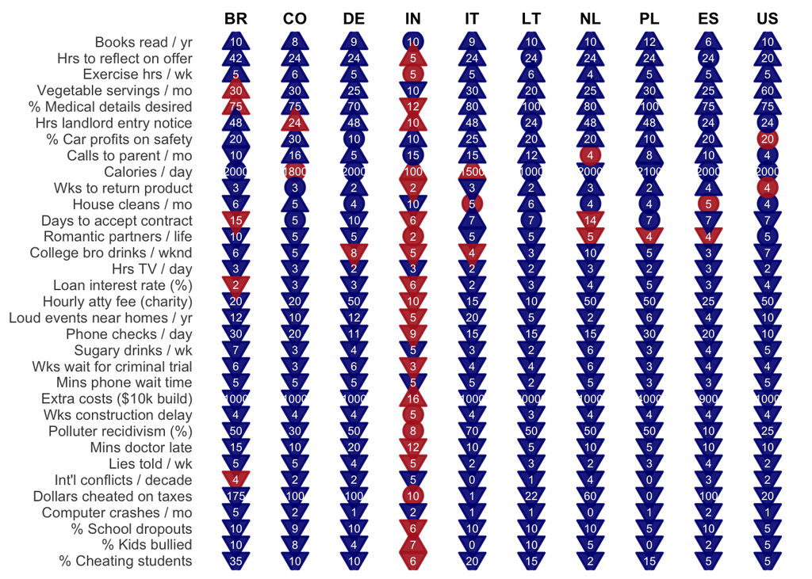

```r
# Create a mapping for question numbers to descriptive labels
question_labels <- c(
  "q1" = "Hrs TV / day", "q2" = "Sugary drinks / wk", "q3" = "Exercise hrs / wk",
  "q4" = "Calories / day", "q5" = "Vegetable servings / mo", "q6" = "Lies told / wk",
  "q7" = "Mins doctor late", "q8" = "Books read / yr", "q9" = "Romantic partners / life",
  "q10" = "Int'l conflicts / decade", "q11" = "Dollars cheated on taxes", "q12" = "% Cheating students",
  "q13" = "Phone checks / day", "q14" = "Mins phone wait time", "q15" = "Calls to parent / mo",
  "q16" = "House cleans / mo", "q17" = "Computer crashes / mo", "q18" = "% School dropouts",
  "q20" = "% Kids bullied", "q21" = "College bro drinks / wknd", "q22" = "Days to accept contract",
  "q23" = "Wks to return product", "q24" = "Hrs to reflect on offer", "q25" = "Extra costs ($10k build)",
  "q26" = "Wks construction delay", "q27" = "Loud events near homes / yr", "q28" = "% Car profits on safety",
  "q29" = "% Medical details desired", "q30" = "Wks wait for criminal trial", "q31" = "Hourly atty fee (charity)",
  "q32" = "Hrs landlord entry notice", "q33" = "Loan interest rate (%)", "q34" = "Polluter recidivism (%)"
)

# Prepare the data for visualization
prepare_figure1_data <- function() {
  # Extract country information
  countries <- unique(Data_All$Country_name)

  # Initialize empty dataframe
  figure1_data <- data.frame()

  # Add Poland expert category if it exists
  if("Poland_Expert" %in% countries) {
    countries <- countries[countries != "Poland_Expert"]
    countries <- c(countries, "Poland_Expert")
  }

  # Process each country
  for(country in countries) {
    country_name <- country
    if(country == "Poland_Expert") {
      country_filter <- "Poland"
      country_name <- "Poland_Expert"
    } else {
      country_filter <- country
    }

    # Filter by country and condition
    if(country == "Poland_Expert") {
      # Special handling for Poland expert data if needed
      country_avg <- Data_All_Average_Pass1 %>%
        filter(Country_name == country_filter, Expert == TRUE)
      country_ideal <- Data_All_Ideal_Pass1 %>%
        filter(Country_name == country_filter, Expert == TRUE)
      country_reasonable <- Data_All_Reasonable_Pass1 %>%
        filter(Country_name == country_filter, Expert == TRUE)
    } else {
      country_avg <- Data_All_Average_Pass1 %>%
        filter(Country_name == country_filter)
      country_ideal <- Data_All_Ideal_Pass1 %>%
        filter(Country_name == country_filter)
      country_reasonable <- Data_All_Reasonable_Pass1 %>%
        filter(Country_name == country_filter)
    }

    # Calculate medians for each question by condition
    for(q in question_cols) {
      if(q %in% colnames(country_avg) && q %in% colnames(country_ideal) && q %in% colnames(country_reasonable)) {
        # Calculate medians
        median_avg <- median(as.numeric(country_avg[[q]]), na.rm = TRUE)
        median_ideal <- median(as.numeric(country_ideal[[q]]), na.rm = TRUE)
        median_reasonable <- median(as.numeric(country_reasonable[[q]]), na.rm = TRUE)

        # Add to dataframe
        figure1_data <- rbind(figure1_data, data.frame(
          Country = country_name,
          Item = q,
          Median_average = median_avg,
          Median_ideal = median_ideal,
          Median_reasonable = median_reasonable
        ))
      }
    }
  }

  return(figure1_data)
}

# Generate the data
figure1_data <- prepare_figure1_data()

# Process the data to match the paper's visualization
processed_data <- figure1_data %>%
  mutate(
    Item_label = question_labels[Item],
    Color = ifelse(Median_reasonable >= Median_average & Median_reasonable <= Median_ideal |
                   Median_reasonable <= Median_average & Median_reasonable >= Median_ideal,
                  "navy", "firebrick"),
    Shape = case_when(
      Median_ideal < Median_average ~ 'Less',      # Downward triangle
      Median_ideal > Median_average ~ 'More',      # Upward triangle
      Median_ideal == Median_average ~ 'Equal'     # Circle
    ),
    Ratio = log2(Median_ideal/Median_average)
  )

# Calculate the ratio for ordering items
item_ratios <- processed_data %>%
  group_by(Item) %>%
  summarize(Avg_ratio = mean(Ratio, na.rm = TRUE))

# Join with the processed data
processed_data <- processed_data %>%
  left_join(item_ratios, by = "Item")

# Define country abbreviation labels
CountryLabels = c(
  'Brazil' = 'BR',
  'Colombia' = 'CO',
  'Germany' = 'DE',
  'India' = 'IN',
  'Italy' = 'IT',
  'Lithuania' = 'LT',
  'Netherlands' = 'NL',
  'Poland' = 'PL',
  'Poland_Expert' = 'PL*',
  'Spain' = 'ES',
  'USA' = 'US'
)

# Update country names to use abbreviations for plotting
processed_data$Country_label <- CountryLabels[processed_data$Country]

# Create the figure
figure1_nofilter <- ggplot(processed_data,
                  aes(x = Country, y = reorder(Item_label, Avg_ratio),
                      fill = Color, color = Color)) +
  geom_point(aes(shape = Shape), size = 5, alpha = 0.9, stroke = 1) +
  geom_text(aes(label = round(Median_reasonable)),
            size = 2.5, color = "white") +
  scale_fill_identity() +
  scale_color_identity() +
  scale_shape_manual(values = c('Equal' = 21, 'Less' = 25, 'More' = 24)) +
  scale_x_discrete(labels = CountryLabels, position = "top") +
  theme_minimal() +
  theme(
    axis.title = element_blank(),
    legend.position = "none",
    text = element_text(color = "black"),
    axis.text.x = element_text(face = "bold", color = "black", size = 10),
    axis.text.y = element_text(size = 9),
    panel.grid.major = element_blank(),
    panel.grid.minor = element_blank()
  )

# Display the figure
print(figure1_nofilter)
```

```r
# Save the figure
ggsave("Figure1_Reasonableness_NoFilter.jpg", figure1_nofilter, dpi = 300, width = 16, height = 25, units = "cm")
```

### Figure 1: Visualization of Reasonable Medians by Country and Item [WITH 3 SD Removed] NEEDS REVISION

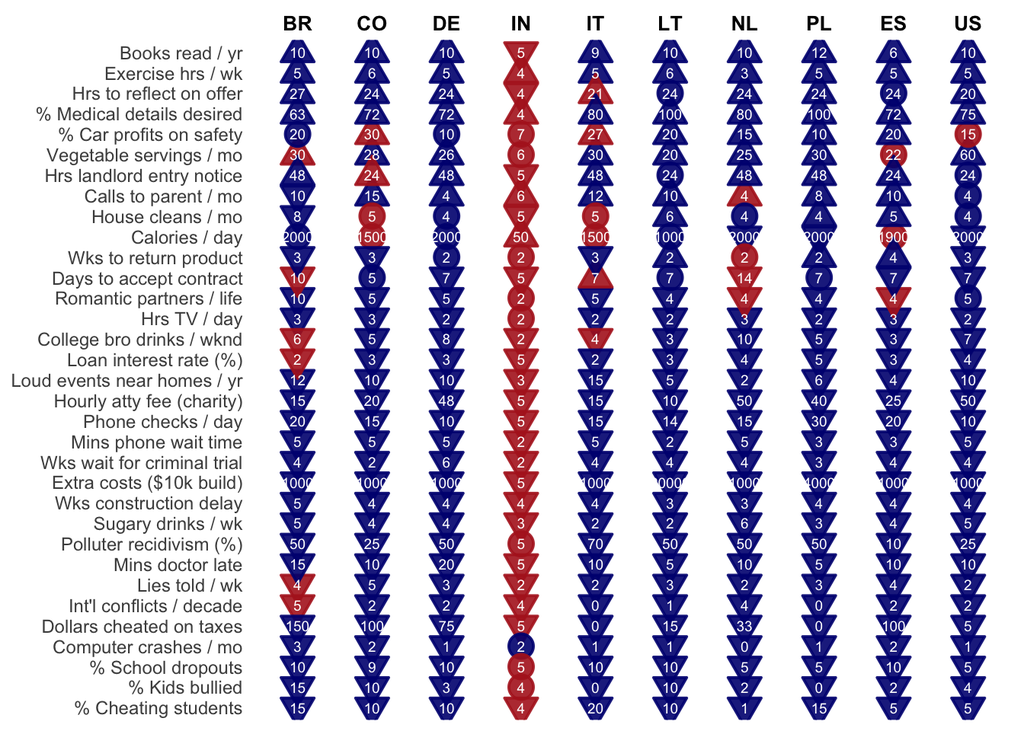

```r
# Create a mapping for question numbers to descriptive labels
question_labels <- c(
  "q1" = "Hrs TV / day", "q2" = "Sugary drinks / wk", "q3" = "Exercise hrs / wk",
  "q4" = "Calories / day", "q5" = "Vegetable servings / mo", "q6" = "Lies told / wk",
  "q7" = "Mins doctor late", "q8" = "Books read / yr", "q9" = "Romantic partners / life",
  "q10" = "Int'l conflicts / decade", "q11" = "Dollars cheated on taxes", "q12" = "% Cheating students",
  "q13" = "Phone checks / day", "q14" = "Mins phone wait time", "q15" = "Calls to parent / mo",
  "q16" = "House cleans / mo", "q17" = "Computer crashes / mo", "q18" = "% School dropouts",
  "q20" = "% Kids bullied", "q21" = "College bro drinks / wknd", "q22" = "Days to accept contract",
  "q23" = "Wks to return product", "q24" = "Hrs to reflect on offer", "q25" = "Extra costs ($10k build)",
  "q26" = "Wks construction delay", "q27" = "Loud events near homes / yr", "q28" = "% Car profits on safety",
  "q29" = "% Medical details desired", "q30" = "Wks wait for criminal trial", "q31" = "Hourly atty fee (charity)",
  "q32" = "Hrs landlord entry notice", "q33" = "Loan interest rate (%)", "q34" = "Polluter recidivism (%)"
)

# Prepare the data for visualization
prepare_figure1_data <- function() {
  # Extract country information
  countries <- unique(Data_All$Country_name)

  # Initialize empty dataframe
  figure1_data <- data.frame()

  # Add Poland expert category if it exists
  if("Poland_Expert" %in% countries) {
    countries <- countries[countries != "Poland_Expert"]
    countries <- c(countries, "Poland_Expert")
  }

  # Process each country
  for(country in countries) {
    country_name <- country
    if(country == "Poland_Expert") {
      country_filter <- "Poland"
      country_name <- "Poland_Expert"
    } else {
      country_filter <- country
    }

    # Filter by country and condition
    if(country == "Poland_Expert") {
      # Special handling for Poland expert data if needed
      country_avg <- Data_All_Average_Filtered %>%
        filter(Country_name == country_filter, Expert == TRUE)
      country_ideal <- Data_All_Ideal_Filtered %>%
        filter(Country_name == country_filter, Expert == TRUE)
      country_reasonable <- Data_All_Reasonable_Filtered %>%
        filter(Country_name == country_filter, Expert == TRUE)
    } else {
      country_avg <- Data_All_Average_Filtered %>%
        filter(Country_name == country_filter)
      country_ideal <- Data_All_Ideal_Filtered %>%
        filter(Country_name == country_filter)
      country_reasonable <- Data_All_Reasonable_Filtered %>%
        filter(Country_name == country_filter)
    }

    # Calculate medians for each question by condition
    for(q in question_cols) {
      if(q %in% colnames(country_avg) && q %in% colnames(country_ideal) && q %in% colnames(country_reasonable)) {
        # Calculate medians
        median_avg <- median(as.numeric(country_avg[[q]]), na.rm = TRUE)
        median_ideal <- median(as.numeric(country_ideal[[q]]), na.rm = TRUE)
        median_reasonable <- median(as.numeric(country_reasonable[[q]]), na.rm = TRUE)

        # Add to dataframe
        figure1_data <- rbind(figure1_data, data.frame(
          Country = country_name,
          Item = q,
          Median_average = median_avg,
          Median_ideal = median_ideal,
          Median_reasonable = median_reasonable
        ))
      }
    }
  }

  return(figure1_data)
}

# Generate the data
figure1_data <- prepare_figure1_data()

# Process the data to match the paper's visualization
processed_data <- figure1_data %>%
  mutate(
    Item_label = question_labels[Item],
    Color = ifelse(Median_reasonable >= Median_average & Median_reasonable <= Median_ideal |
                   Median_reasonable <= Median_average & Median_reasonable >= Median_ideal,
                  "navy", "firebrick"),
    Shape = case_when(
      Median_ideal < Median_average ~ 'Less',      # Downward triangle
      Median_ideal > Median_average ~ 'More',      # Upward triangle
      Median_ideal == Median_average ~ 'Equal'     # Circle
    ),
    Ratio = log2(Median_ideal/Median_average)
  )

# Calculate the ratio for ordering items
item_ratios <- processed_data %>%
  group_by(Item) %>%
  summarize(Avg_ratio = mean(Ratio, na.rm = TRUE))

# Join with the processed data
processed_data <- processed_data %>%
  left_join(item_ratios, by = "Item")

# Define country abbreviation labels
CountryLabels = c(
  'Brazil' = 'BR',
  'Colombia' = 'CO',
  'Germany' = 'DE',
  'India' = 'IN',
  'Italy' = 'IT',
  'Lithuania' = 'LT',
  'Netherlands' = 'NL',
  'Poland' = 'PL',
  'Poland_Expert' = 'PL*',
  'Spain' = 'ES',
  'USA' = 'US'
)

# Update country names to use abbreviations for plotting
processed_data$Country_label <- CountryLabels[processed_data$Country]

# Create the figure
figure1_filtered <- ggplot(processed_data,
                  aes(x = Country, y = reorder(Item_label, Avg_ratio),
                      fill = Color, color = Color)) +
  geom_point(aes(shape = Shape), size = 5, alpha = 0.9, stroke = 1) +
  geom_text(aes(label = round(Median_reasonable)),
            size = 2.5, color = "white") +
  scale_fill_identity() +
  scale_color_identity() +
  scale_shape_manual(values = c('Equal' = 21, 'Less' = 25, 'More' = 24)) +
  scale_x_discrete(labels = CountryLabels, position = "top") +
  theme_minimal() +
  theme(
    axis.title = element_blank(),
    legend.position = "none",
    text = element_text(color = "black"),
    axis.text.x = element_text(face = "bold", color = "black", size = 10),
    axis.text.y = element_text(size = 9),
    panel.grid.major = element_blank(),
    panel.grid.minor = element_blank()
  )

# Display the figure
print(figure1_filtered)
```

```r
# Save the figure
ggsave("Figure1_Reasonableness_Filtered.jpg", figure1_filtered, dpi = 300, width = 16, height = 25, units = "cm")
```

### Table 3 for Paper

```r
# 1. Define question labels for clear output
question_labels <- c("q1"="Hrs TV / day", "q2"="Sugary drinks / wk", "q3"="Exercise hrs / wk", "q4"="Calories / day", "q5"="Vegetable servings / mo", "q6"="Lies told / wk", "q7"="Mins doctor late", "q8"="Books read / yr", "q9"="Romantic partners / life", "q10"="Int'l conflicts / decade", "q11"="Dollars cheated on taxes", "q12"="% Cheating students", "q13"="Phone checks / day", "q14"="Mins phone wait time", "q15"="Calls to parent / mo", "q16"="House cleans / mo", "q17"="Computer crashes / mo", "q18"="% School dropouts", "q20"="% Kids bullied", "q21"="College bro drinks / wknd", "q22"="Days to accept contract", "q23"="Wks to return product", "q24"="Hrs to reflect on offer", "q25"="Extra costs ($10k build)", "q26"="Wks construction delay", "q27"="Loud events near homes / yr", "q28"="% Car profits on safety", "q29"="% Medical details desired", "q30"="Wks wait for criminal trial", "q31"="Hourly atty fee (charity)", "q32"="Hrs landlord entry notice", "q33"="Loan interest rate (%)", "q34"="Polluter recidivism (%)")

# 2. Reusable function to calculate and format medians for any given dataset
prepare_median_data <- function(avg_data, ideal_data, reasonable_data) {

  # Bind the rows from the three conditions
  combined_data <- bind_rows(avg_data, ideal_data, reasonable_data)

  # Calculate medians
  all_medians <- combined_data %>%
    # Reshape data to long format to calculate medians efficiently
    pivot_longer(cols = all_of(question_cols), names_to = "Item", values_to = "Response") %>%
    # Group by all necessary variables
    group_by(Country_name, Item, Condition_name) %>%
    # Calculate the median for each group, ignoring NA values
    summarise(Median_Response = median(Response, na.rm = TRUE), .groups = 'drop') %>%
    # Pivot back to a wide format with columns for Average, Ideal, and Reasonable
    pivot_wider(names_from = Condition_name, values_from = Median_Response) %>%
    # Add readable labels for questions
    mutate(Item_Label = question_labels[Item]) %>%
    # Select and reorder columns for the final table
    select(Country = Country_name, `Item Label` = Item_Label, Average, Ideal, Reasonable) %>%
    # Sort the final table for readability
    arrange(Country, `Item Label`)

  return(all_medians)
}

# --- TABLE 1: GENERATE AND DISPLAY "NO 3SD REMOVAL" DATA ---

# Call the function using the datasets that passed the attention check
no_3sd_table <- prepare_median_data(
  Data_All_Average_Pass1,
  Data_All_Ideal_Pass1,
  Data_All_Reasonable_Pass1
)

# Display the complete "NO 3SD" table using kable
cat("### Complete Median Table (NO 3SD Removal)\n\n")
```

```
## ### Complete Median Table (NO 3SD Removal)
```

```r
print(kable(no_3sd_table, format = "pipe", align = "llrrr"))
```

```
##
##
## |Country     |Item Label                  |  Average|    Ideal| Reasonable|
## |:-----------|:---------------------------|--------:|--------:|----------:|
## |Brazil      |% Car profits on safety     |    17.50|    20.00|      20.00|
## |Brazil      |% Cheating students         |    80.00|    15.00|      35.00|
## |Brazil      |% Kids bullied              |    40.00|     0.00|      10.00|
## |Brazil      |% Medical details desired   |    55.00|    70.00|      75.00|
## |Brazil      |% School dropouts           |    27.50|     5.00|      10.00|
## |Brazil      |Books read / yr             |     5.00|    12.00|      10.00|
## |Brazil      |Calls to parent / mo        |    15.00|    10.00|      10.00|
## |Brazil      |Calories / day              |  2000.00|  2000.00|    2000.00|
## |Brazil      |College bro drinks / wknd   |    10.00|     6.00|       6.00|
## |Brazil      |Computer crashes / mo       |     9.00|     0.02|       5.00|
## |Brazil      |Days to accept contract     |    10.00|     7.00|      15.00|
## |Brazil      |Dollars cheated on taxes    |  1000.00|     0.00|     175.00|
## |Brazil      |Exercise hrs / wk           |     4.00|     5.00|       5.00|
## |Brazil      |Extra costs ($10k build)    |  3000.00|  1000.00|    1000.00|
## |Brazil      |Hourly atty fee (charity)   |    25.00|    10.00|      20.00|
## |Brazil      |House cleans / mo           |     7.00|     5.00|       6.00|
## |Brazil      |Hrs TV / day                |     3.00|     2.00|       3.00|
## |Brazil      |Hrs landlord entry notice   |    24.00|    48.00|      48.00|
## |Brazil      |Hrs to reflect on offer     |    12.00|    48.00|      42.00|
## |Brazil      |Int'l conflicts / decade    |     4.00|     1.00|       4.50|
## |Brazil      |Lies told / wk              |    13.00|     5.00|       5.00|
## |Brazil      |Loan interest rate (%)      |    10.00|     5.00|       1.50|
## |Brazil      |Loud events near homes / yr |    28.50|    11.00|      12.00|
## |Brazil      |Mins doctor late            |    27.50|    10.00|      15.00|
## |Brazil      |Mins phone wait time        |    16.00|     3.00|       5.00|
## |Brazil      |Phone checks / day          |    42.50|    20.00|      30.00|
## |Brazil      |Polluter recidivism (%)     |    60.00|    35.00|      50.00|
## |Brazil      |Romantic partners / life    |    10.00|     6.00|       9.50|
## |Brazil      |Sugary drinks / wk          |    10.00|     4.00|       7.00|
## |Brazil      |Vegetable servings / mo     |    20.00|    27.50|      30.00|
## |Brazil      |Wks construction delay      |     9.00|     3.00|       4.00|
## |Brazil      |Wks to return product       |     3.00|     2.00|       3.00|
## |Brazil      |Wks wait for criminal trial |    12.00|     4.00|       5.50|
## |Colombia    |% Car profits on safety     |    20.00|    30.00|      30.00|
## |Colombia    |% Cheating students         |    30.00|     3.00|      10.00|
## |Colombia    |% Kids bullied              |    20.00|     1.00|       7.50|
```

[output cut: 279 more lines]

```
## |USA         |Hrs to reflect on offer     |    10.00|    24.00|      20.00|
## |USA         |Int'l conflicts / decade    |     5.00|     0.00|       2.00|
## |USA         |Lies told / wk              |     7.00|     0.00|       2.00|
## |USA         |Loan interest rate (%)      |     7.00|     3.00|       4.00|
## |USA         |Loud events near homes / yr |    12.00|     6.00|      10.00|
## |USA         |Mins doctor late            |    15.00|     5.00|      10.00|
## |USA         |Mins phone wait time        |    15.00|     2.00|       5.00|
## |USA         |Phone checks / day          |    25.00|     8.00|      10.00|
## |USA         |Polluter recidivism (%)     |    50.00|     5.00|      25.00|
## |USA         |Romantic partners / life    |     5.00|     5.00|       5.00|
## |USA         |Sugary drinks / wk          |     7.00|     2.00|       5.00|
## |USA         |Vegetable servings / mo     |    24.00|    60.00|      60.00|
## |USA         |Wks construction delay      |     7.00|     2.00|       4.00|
## |USA         |Wks to return product       |     3.00|     3.00|       4.00|
## |USA         |Wks wait for criminal trial |    16.00|     4.00|       4.00|
```

```r
# --- TABLE 2: GENERATE AND DISPLAY "WITH 3SD REMOVAL" DATA ---

# Call the function using the datasets that have had 3SD outliers removed
with_3sd_table <- prepare_median_data(
  Data_All_Average_Filtered,
  Data_All_Ideal_Filtered,
  Data_All_Reasonable_Filtered
)

# Display the complete "WITH 3SD" table using kable
cat("\n\n### Complete Median Table (WITH 3SD Removal)\n\n")
```

```
##
##
## ### Complete Median Table (WITH 3SD Removal)
```

```r
print(kable(with_3sd_table, format = "pipe", align = "llrrr"))
```

```
##
##
## |Country     |Item Label                  | Average|    Ideal| Reasonable|
## |:-----------|:---------------------------|-------:|--------:|----------:|
## |Brazil      |% Car profits on safety     |    20.0|    20.00|      20.00|
## |Brazil      |% Cheating students         |    70.0|    10.00|      15.00|
## |Brazil      |% Kids bullied              |    30.0|     0.00|      15.00|
## |Brazil      |% Medical details desired   |    40.0|    70.00|      63.33|
## |Brazil      |% School dropouts           |    30.0|     3.00|      10.00|
## |Brazil      |Books read / yr             |     5.0|    12.50|      10.00|
## |Brazil      |Calls to parent / mo        |    12.5|    10.00|      10.00|
## |Brazil      |Calories / day              |  2000.0|  2000.00|    2000.00|
## |Brazil      |College bro drinks / wknd   |    10.0|     6.00|       5.50|
## |Brazil      |Computer crashes / mo       |     8.0|     0.00|       3.00|
## |Brazil      |Days to accept contract     |     8.5|     7.00|      10.00|
## |Brazil      |Dollars cheated on taxes    |  1000.0|     0.00|     150.00|
## |Brazil      |Exercise hrs / wk           |     4.0|     5.00|       5.00|
## |Brazil      |Extra costs ($10k build)    |  2800.0|   500.00|    1000.00|
## |Brazil      |Hourly atty fee (charity)   |    35.0|    10.00|      15.00|
## |Brazil      |House cleans / mo           |     8.0|     5.00|       8.00|
## |Brazil      |Hrs TV / day                |     3.0|     1.25|       3.00|
## |Brazil      |Hrs landlord entry notice   |    24.0|    48.00|      48.00|
## |Brazil      |Hrs to reflect on offer     |    10.0|    48.00|      27.00|
## |Brazil      |Int'l conflicts / decade    |     4.0|     1.00|       5.00|
## |Brazil      |Lies told / wk              |    14.5|     5.00|       4.00|
## |Brazil      |Loan interest rate (%)      |    10.0|     3.00|       2.00|
## |Brazil      |Loud events near homes / yr |    27.0|     5.00|      12.00|
## |Brazil      |Mins doctor late            |    27.5|     5.00|      15.00|
## |Brazil      |Mins phone wait time        |    16.0|     3.00|       5.00|
## |Brazil      |Phone checks / day          |    47.5|    10.00|      20.00|
## |Brazil      |Polluter recidivism (%)     |    60.0|    27.50|      50.00|
## |Brazil      |Romantic partners / life    |    10.0|     8.00|      10.00|
## |Brazil      |Sugary drinks / wk          |    10.0|     2.50|       5.00|
## |Brazil      |Vegetable servings / mo     |    20.0|    25.00|      30.00|
## |Brazil      |Wks construction delay      |     8.0|     2.00|       5.00|
## |Brazil      |Wks to return product       |     3.0|     2.00|       3.00|
## |Brazil      |Wks wait for criminal trial |    21.5|     4.00|       4.00|
## |Colombia    |% Car profits on safety     |    20.0|    27.50|      30.00|
## |Colombia    |% Cheating students         |    20.0|     2.00|      10.00|
## |Colombia    |% Kids bullied              |    16.0|     0.50|      10.00|
```

[output cut: 279 more lines]

```
## |USA         |Hrs to reflect on offer     |    10.0|    24.00|      20.00|
## |USA         |Int'l conflicts / decade    |     5.0|     0.00|       2.00|
## |USA         |Lies told / wk              |     7.0|     0.00|       2.00|
## |USA         |Loan interest rate (%)      |     7.0|     3.00|       4.00|
## |USA         |Loud events near homes / yr |    12.0|     5.00|      10.00|
## |USA         |Mins doctor late            |    15.0|     5.00|      10.00|
## |USA         |Mins phone wait time        |    15.0|     2.00|       5.00|
## |USA         |Phone checks / day          |    25.0|     5.00|      10.00|
## |USA         |Polluter recidivism (%)     |    50.0|     4.00|      25.00|
## |USA         |Romantic partners / life    |     5.0|     5.00|       5.00|
## |USA         |Sugary drinks / wk          |     7.5|     2.00|       5.00|
## |USA         |Vegetable servings / mo     |    24.0|    60.00|      60.00|
## |USA         |Wks construction delay      |     6.0|     2.00|       4.00|
## |USA         |Wks to return product       |     3.0|     2.00|       3.00|
## |USA         |Wks wait for criminal trial |    14.0|     3.50|       4.00|
```